# Etapa 1 · Comprensión de los datos, diagnóstico de calidad e imputación

- Mostrar todo el código
- Ocultar todo el código
- Ver el código fuente

**Estructura (CRISP-DM, etapa 2):**

1. Comprensión de los datos: dimensión, diccionario de variables y catálogo de estaciones.
2. Calidad de los datos: faltantes, espurios/erróneos, consistencia física y duplicados.
3. Imputación: diagnóstico de huecos, estrategia justificada, validación por enmascaramiento sintético y aplicación.

# 1 Configuración y paquetes

Se cargan los paquetes y se fijan los parámetros que controlan todo el análisis. Concentrarlos en un solo chunk permite cambiar decisiones (por ejemplo, el umbral que separa una variable “no medida” de una con fallas) sin tocar el resto del código.

- `tidyverse`: manipulación y gráficos. `readxl` / `data.table`: lectura de Excel / CSV grandes.
- `imputeTS`: imputación de series de tiempo [@moritz2017].
- `lubridate`: fechas. `scales` y `knitr`: formato de tablas y números.

**Código**

```r
library(tidyverse)
library(readxl)
library(lubridate)
library(imputeTS)
library(scales)
library(knitr)
library(missForest)
library(VIM)

theme_set(theme_minimal(base_size = 11))
set.seed(2026)                       # reproducibilidad (enmascaramiento sintético)

# ---- Parámetros del análisis ------------------------------------------------
ruta_datos          <- "../data/BD_2020_2026_concatenada.xlsx"  # cambiar por la base concatenada 2020-2026
formato             <- "excel_hojas"         # "excel_hojas" (1 hoja por estación) o "csv_largo"
umbral_estructural  <- 95    # % de NA anual desde el cual una variable se considera "no medida"
umbral_cobertura    <- 50    # % de NA anual desde el cual la cobertura se considera "baja"
huecos_cortos       <- 6     # horas: límite del nivel 1 de imputación
huecos_medios       <- 72    # horas: límite del nivel 2 de imputación
anio_benchmark      <- 2020  # año usado para validar los métodos de imputación
dir.create("salidas", showWarnings = FALSE)
```

# 2 Comprensión de los datos

## 2.1 Lectura y estandarización de la base

La base de SIMA llega en el sigueinte formato: cada hoja de Excel es una estación y cada fila una hora. Para analizarla como una sola tabla se leen todas las hojas, se agrega una columna `estacion` con el nombre de la hoja y se apilan (formato *largo por estación*, una fila = una estación en una hora).

También se estandarizan los nombres: `Fecha y hora` pasa a `fecha`, `PM2.5` a `PM25` (un punto en el nombre complica el código en R) y `NOX`/`NOx` a `NOX`. La zona horaria se fija en UTC para que los cambios de horario de verano no creen horas duplicadas o inexistentes artificiales (los datos son horas locales “de reloj” sin zona).

**Código**

```r
leer_bd <- function(ruta, formato) {
  if (formato == "excel_hojas") {
    excel_sheets(ruta) |>
      map_dfr(\(h) read_excel(ruta, sheet = h, guess_max = 1e6) |>
                 mutate(estacion = h, .before = 1))
  } else {
    data.table::fread(ruta) |> as_tibble()
  }
}

crudo <- leer_bd(ruta_datos, formato) |>
  rename_with(\(n) case_when(
    n %in% c("Fecha y hora", "Fecha", "fecha", "datetime") ~ "fecha",
    n %in% c("PM2.5", "PM25") ~ "PM25",
    toupper(n) == "NOX" ~ "NOX",
    TRUE ~ n
  )) |>
  mutate(
    fecha = force_tz(as.POSIXct(fecha), "UTC"),
    anio = year(fecha),
    .after = fecha
  ) |>
  select(-date)

vars <- c("CO","NO","NO2","NOX","O3","PM10","PM25","SO2",      # contaminantes
          "TOUT","RH","SR","RAINF","PRS","WSR","WDR")           # meteorología
stopifnot(all(vars %in% names(crudo)))
glimpse(crudo)
```

```
Rows: 830,908
Columns: 18
$ estacion <chr> "SE", "SE", "SE", "SE", "SE", "SE", "SE", "SE", "SE", "SE", "…
$ fecha    <dttm> 2020-01-01 00:00:00, 2020-01-01 01:00:00, 2020-01-01 02:00:0…
$ anio     <dbl> 2020, 2020, 2020, 2020, 2020, 2020, 2020, 2020, 2020, 2020, 2…
$ CO       <dbl> NA, 2.11, 2.06, 1.96, 1.98, 2.06, 1.94, 2.06, 1.94, 2.03, 2.0…
$ NO       <dbl> NA, NA, NA, NA, NA, NA, NA, NA, NA, NA, NA, NA, NA, NA, NA, N…
$ NO2      <dbl> NA, NA, NA, NA, NA, NA, NA, NA, NA, NA, NA, NA, NA, NA, NA, N…
$ NOX      <dbl> NA, NA, NA, NA, NA, NA, NA, NA, NA, NA, NA, NA, NA, NA, NA, N…
$ O3       <dbl> NA, 19, 19, 19, 16, 13, 15, 10, 12, 7, 8, 9, 10, 8, 16, 25, 2…
$ PM10     <dbl> 66, 57, 68, 68, 48, 42, 38, 33, 36, 21, 35, 37, 31, 28, 26, 2…
$ PM25     <dbl> 54.23, NA, 53.84, 36.47, 33.59, 33.42, 20.20, 23.84, 15.65, N…
$ PRS      <dbl> NA, 735.7, 734.8, 734.2, 733.9, 733.8, 733.8, 733.6, 733.6, 7…
$ RAINF    <dbl> NA, 0.00, 0.00, 0.00, 0.00, 0.02, 0.10, 0.06, 0.02, 0.04, 0.0…
$ RH       <dbl> NA, 96, 96, 96, 96, 96, 96, 96, NA, NA, NA, NA, 95, 95, 93, 8…
$ SO2      <dbl> NA, 5.4, 5.5, 5.4, 5.5, 5.4, 5.4, NA, NA, NA, NA, NA, NA, 5.5…
$ SR       <dbl> 0.000, 0.010, 0.010, 0.010, 0.010, 0.010, 0.010, 0.010, 0.012…
$ TOUT     <dbl> NA, 11.20, 11.26, 11.35, 11.47, 11.69, 11.71, 11.84, 11.89, 1…
$ WSR      <dbl> NA, 8.1, 5.5, 3.8, 3.3, 3.5, 2.9, 3.8, 3.0, 11.2, 13.0, 4.4, …
$ WDR      <dbl> NA, NA, NA, NA, NA, NA, NA, NA, NA, NA, NA, NA, NA, NA, NA, N…
```

Se verifica abajo que las 15 variables quedaron numéricas.

**Código**

```r
tipos <- crudo |> select(all_of(vars)) |> map_chr(\(x) class(x)[1])
stopifnot(all(tipos == "numeric"))
table(tipos)
```

```
tipos
numeric
     15
```

**Código**

```r
# Antes de convertir, mira el contexto de los 999
crudo |> filter(PM10 == 999 | PM25 == 999) |> select(estacion, fecha, PM10, PM25)
```

| estacion | fecha | PM10 | PM25 |
| --- | --- | --- | --- |
| NE | 2024-01-01 00:00:00 | 945 | 999 |
| SO2 | 2023-02-12 06:00:00 | 999 | 17 |
| SO2 | 2024-03-30 05:00:00 | 999 | 10 |

**Código**

```r
# Conversión: -9999 en todas las variables; 999 solo en PM10 y PM25
crudo <- crudo |>
  mutate(across(all_of(vars), \(x) replace(x, x %in% -9999, NA_real_)),
         across(c(PM10, PM25), \(x) replace(x, x %in% 999, NA_real_)))
```

## 2.2 Dimensión del dataset

Se reporta el número de registros (filas), columnas, estaciones, periodo cubierto y el número de celdas de medición (registros × variables). Un registro es *una estación en una hora*.

**Código**

```r
dimension <- tibble(
  Registros              = nrow(crudo),
  Columnas               = ncol(crudo),
  `Variables de medición`= length(vars),
  Estaciones             = n_distinct(crudo$estacion),
  Inicio                 = min(crudo$fecha),
  Fin                    = max(crudo$fecha),
  `Celdas de medición`   = nrow(crudo) * length(vars)
)
dimension |> mutate(across(where(is.numeric), \(x) comma(x))) |> t() |>
  kable(col.names = "Valor", caption = "Dimensión de la base cargada")
```

Dimensión de la base cargada

|  | Valor |
| --- | --- |
| Registros | 830,908 |
| Columnas | 18 |
| Variables de medición | 15 |
| Estaciones | 15 |
| Inicio | 2020-01-01 |
| Fin | 2026-07-31 23:00:00 |
| Celdas de medición | 12,463,620 |

Nota: `Columnas` incluye `estacion` y `anio`, columnas que agregamos nosotros; la base original de cada hoja tiene 16 columnas (`Fecha y hora` + 15 variables).

## 2.3 Integridad del índice temporal: horas ausentes y duplicados

Se cuenta, por estación, cuántas horas existen, cuántas faltan como *filas ausentes* (distinto de una fila presente con valores vacíos) y si hay marcas de tiempo duplicadas.

**Código**

```r
integridad <- crudo |>
  group_by(estacion) |>
  summarise(
    filas          = n(),
    fechas_unicas  = n_distinct(fecha),
    duplicadas     = filas - fechas_unicas,
    primera        = min(fecha), ultima = max(fecha),
    esperadas      = as.integer(difftime(ultima, primera, units = "hours")) + 1L,
    horas_ausentes = esperadas - fechas_unicas,
    .groups = "drop")
kable(integridad, caption = "Integridad del índice horario por estación")
```

Integridad del índice horario por estación

| estacion | filas | fechas_unicas | duplicadas | primera | ultima | esperadas | horas_ausentes |
| --- | --- | --- | --- | --- | --- | --- | --- |
| CE | 57692 | 57692 | 0 | 2020-01-01 00:00:00 | 2026-07-31 23:00:00 | 57696 | 4 |
| NE | 57682 | 57682 | 0 | 2020-01-01 00:00:00 | 2026-07-31 23:00:00 | 57696 | 14 |
| NE2 | 57680 | 57680 | 0 | 2020-01-01 00:00:00 | 2026-07-31 23:00:00 | 57696 | 16 |
| NE3 | 48904 | 48904 | 0 | 2021-01-01 00:00:00 | 2026-07-31 23:00:00 | 48912 | 8 |
| NO | 57684 | 57684 | 0 | 2020-01-01 00:00:00 | 2026-07-31 23:00:00 | 57696 | 12 |
| NO2 | 57681 | 57681 | 0 | 2020-01-01 00:00:00 | 2026-07-31 23:00:00 | 57696 | 15 |
| NO3 | 32132 | 32132 | 0 | 2022-12-01 01:00:00 | 2026-07-31 23:00:00 | 32135 | 3 |
| NTE | 57682 | 57682 | 0 | 2020-01-01 00:00:00 | 2026-07-31 23:00:00 | 57696 | 14 |
| NTE2 | 57680 | 57680 | 0 | 2020-01-01 00:00:00 | 2026-07-31 23:00:00 | 57696 | 16 |
| SE | 57686 | 57686 | 0 | 2020-01-01 00:00:00 | 2026-07-31 23:00:00 | 57696 | 10 |
| SE2 | 57682 | 57682 | 0 | 2020-01-01 00:00:00 | 2026-07-31 23:00:00 | 57696 | 14 |
| SE3 | 57680 | 57680 | 0 | 2020-01-01 00:00:00 | 2026-07-31 23:00:00 | 57696 | 16 |
| SO | 57684 | 57684 | 0 | 2020-01-01 00:00:00 | 2026-07-31 23:00:00 | 57696 | 12 |
| SO2 | 57680 | 57680 | 0 | 2020-01-01 00:00:00 | 2026-07-31 23:00:00 | 57696 | 16 |
| SUR | 57679 | 57679 | 0 | 2020-01-01 00:00:00 | 2026-07-31 23:00:00 | 57696 | 17 |

**Código**

```r
cat("Filas completamente duplicadas en toda la base:", sum(duplicated(crudo)), "\n")
```

```
Filas completamente duplicadas en toda la base: 0
```

Para poder tratar los huecos como series de tiempo regulares, se **completa la extensión horaria** de cada estación, en donde las horas ausentes se insertan como filas con todas las variables en `NA`. Así, una hora ausente y una hora con sensor sin dato quedan representadas igual (ambas son *dato faltante*).

**Código**

```r
malla <- crudo |>
group_by(estacion) |>
summarise(fecha = list(seq(min(fecha), max(fecha), by = "hour")), .groups = "drop") |>

unnest(fecha)

datos <- malla |>
  left_join(crudo |> distinct(estacion, fecha, .keep_all = TRUE), by = c("estacion", "fecha")) |>
  mutate(anio = year(fecha), mes = month(fecha), hora = hour(fecha),
         estacion = factor(estacion))

cat("Filas tras completar el horario:", comma(nrow(datos)),
    "| filas insertadas:", comma(nrow(datos) - nrow(crudo)), "\n")
```

```
Filas tras completar el horario: 831,095 | filas insertadas: 187
```

## 2.4 Catálogo de estaciones

Las estaciones se describen combinando la Tabla 1 del archivo de etiquetas y el documento de ubicación con coordenadas y elevación de cada estación. La elevación importa para el análisis posterior, ya que afecta la presión atmosférica y la dispersión de contaminantes (por ejemplo, SO y NO2 están a 674 y 702 msnm, mientras SE3 está a 334 msnm).

**Código**

```r
dms <- function(s) {                       # "25°39’55’’N" -> grados decimales
  p <- as.numeric(str_extract_all(s, "[0-9]+")[[1]])
  signo <- if (str_detect(s, "[SW]")) -1 else 1
  signo * (p[1] + p[2]/60 + p[3]/3600)
}
catalogo <- tribble(
  ~clave, ~zona,        ~estacion_nombre, ~municipio,                 ~lat_dms,        ~lon_dms,         ~msnm,
  "SE",   "Sureste",    "La Pastora",     "Guadalupe",                "25°39’55’’N",   "100°14’37’’W",   500,
  "NE",   "Noreste",    "San Nicolás",    "San Nicolás de los Garza", "25°44’41’’N",   "100°15’11’’W",   474,
  "CE",   "Centro",     "Obispado",       "Monterrey",                "25°40’33’’N",   "100°20’18’’W",   562,
  "NO",   "Noroeste",   "San Bernabé",    "Monterrey",                "25°45’46’’N",   "100°22’09’’W",   568,
  "SO",   "Suroeste",   "Santa Catarina", "Santa Catarina",           "25°40’32’’N",   "100°27’29’’W",   674,
  "NO2",  "Noroeste 2", "García",         "García",                   "25°48’01’’N",   "100°35’04’’W",   702,
  "NTE",  "Norte",      "Escobedo",       "Escobedo",                 "25°47’55’’N",   "100°19’38’’W",   503,
  "NE2",  "Noreste 2",  "Apodaca",        "Apodaca",                  "25°46’38’’N",   "100°11’17’’W",   432,
  "SE2",  "Sureste 2",  "Juárez",         "Juárez",                   "25°38’45’’N",   "100°05’43’’W",   387,
  "SO2",  "Suroeste 2", "San Pedro",      "San Pedro Garza García",   "25°39’54’’N",   "100°24’46’’W",   636,
  "SE3",  "Sureste 3",  "Cadereyta",      NA,                         "25°36’04’’N",   "99°59’57’’W",    334,
  "SUR",  "Sur",        "Pueblo Serena",  NA,                         "25°37’01’’N",   "100°16’26’’W",   555,
  "NTE2", "Norte 2",    "Universidad",    NA,                         "25°43’47’’N",   "100°18’36’’W",   520,
  "NE3",  "Noreste 3",  NA,               NA,                         "25°47’26’’N",   "100°04’42’’W",   346,
  "NO3",  "Noroeste 3", NA,               NA,                         "25°46’06’’N",   "100°27’49’’W",   607
) |>
  mutate(lat = map_dbl(lat_dms, dms), lon = map_dbl(lon_dms, dms))

catalogo |>
  select(clave, zona, estacion_nombre, municipio, lat, lon, msnm) |>
  kable(digits = 4, caption = "Catálogo de estaciones (NA = dato no indicado en la documentación)")
```

Catálogo de estaciones (NA = dato no indicado en la documentación)

| clave | zona | estacion_nombre | municipio | lat | lon | msnm |
| --- | --- | --- | --- | --- | --- | --- |
| SE | Sureste | La Pastora | Guadalupe | 25.6653 | -100.2436 | 500 |
| NE | Noreste | San Nicolás | San Nicolás de los Garza | 25.7447 | -100.2531 | 474 |
| CE | Centro | Obispado | Monterrey | 25.6758 | -100.3383 | 562 |
| NO | Noroeste | San Bernabé | Monterrey | 25.7628 | -100.3692 | 568 |
| SO | Suroeste | Santa Catarina | Santa Catarina | 25.6756 | -100.4581 | 674 |
| NO2 | Noroeste 2 | García | García | 25.8003 | -100.5844 | 702 |
| NTE | Norte | Escobedo | Escobedo | 25.7986 | -100.3272 | 503 |
| NE2 | Noreste 2 | Apodaca | Apodaca | 25.7772 | -100.1881 | 432 |
| SE2 | Sureste 2 | Juárez | Juárez | 25.6458 | -100.0953 | 387 |
| SO2 | Suroeste 2 | San Pedro | San Pedro Garza García | 25.6650 | -100.4128 | 636 |
| SE3 | Sureste 3 | Cadereyta | NA | 25.6011 | -99.9992 | 334 |
| SUR | Sur | Pueblo Serena | NA | 25.6169 | -100.2739 | 555 |
| NTE2 | Norte 2 | Universidad | NA | 25.7297 | -100.3100 | 520 |
| NE3 | Noreste 3 | NA | NA | 25.7906 | -100.0783 | 346 |
| NO3 | Noroeste 3 | NA | NA | 25.7683 | -100.4636 | 607 |

## 2.5 Diccionario de variables

El diccionario se arma a partir de las Tablas 2 y 3 del archivo de etiquetas, y se complementa con estadísticos calculados de la base (número de observaciones, % de nulos y rango observado).

**Código**

```r
descr <- tribble(
  ~variable, ~nombre,                        ~grupo,           ~unidad,   ~tipo,
  "CO",   "Monóxido de carbono",             "Contaminante",   "ppm",     "Numérica continua",
  "NO",   "Monóxido de nitrógeno",           "Contaminante",   "ppb",     "Numérica continua",
  "NO2",  "Dióxido de nitrógeno",            "Contaminante",   "ppb",     "Numérica continua",
  "NOX",  "Óxidos de nitrógeno (NO + NO2)",  "Contaminante",   "ppb",     "Numérica continua",
  "O3",   "Ozono",                           "Contaminante",   "ppb",     "Numérica continua",
  "PM10", "Partículas < 10 µm",              "Contaminante",   "µg/m3",   "Numérica continua",
  "PM25", "Partículas < 2.5 µm",             "Contaminante",   "µg/m3",   "Numérica continua",
  "SO2",  "Dióxido de azufre",               "Contaminante",   "ppb",     "Numérica continua",
  "TOUT", "Temperatura",                     "Meteorológica",  "°C",      "Numérica continua",
  "RH",   "Humedad relativa",                "Meteorológica",  "%",       "Numérica continua (0–100)",
  "SR",   "Radiación solar",                 "Meteorológica",  "kW/m2",   "Numérica continua (cero de noche)",
  "RAINF","Precipitación",                   "Meteorológica",  "mm/h",    "Numérica semicontinua (mayoría ceros)",
  "PRS",  "Presión atmosférica",             "Meteorológica",  "mm Hg",   "Numérica continua",
  "WSR",  "Velocidad del viento",            "Meteorológica",  "km/h",    "Numérica continua (> 0)",
  "WDR",  "Dirección del viento",            "Meteorológica",  "°",       "Numérica circular (0–360)"
)

estad <- map_dfr(vars, \(v) {
  x <- datos[[v]]
  tibble(variable = v, n_obs = sum(!is.na(x)), pct_nulos = mean(is.na(x)) * 100,
         min = min(x, na.rm = TRUE), q1 = quantile(x, .25, na.rm = TRUE),
         mediana = median(x, na.rm = TRUE), media = mean(x, na.rm = TRUE),
         q3 = quantile(x, .75, na.rm = TRUE), max = max(x, na.rm = TRUE),
         sd = sd(x, na.rm = TRUE), pct_ceros = mean(x == 0, na.rm = TRUE) * 100)
})

diccionario <- descr |> left_join(estad, by = "variable")
diccionario |>
  select(variable, nombre, grupo, unidad, tipo, n_obs, pct_nulos, min, mediana, media, max) |>
  kable(digits = 2, format.args = list(big.mark = ","),
        caption = "Diccionario de variables con estadísticos observados (antes de limpiar)")
```

Diccionario de variables con estadísticos observados (antes de limpiar)

| variable | nombre | grupo | unidad | tipo | n_obs | pct_nulos | min | mediana | media | max |
| --- | --- | --- | --- | --- | --- | --- | --- | --- | --- | --- |
| CO | Monóxido de carbono | Contaminante | ppm | Numérica continua | 719,098 | 13.48 | 0.00 | 1.15 | 1.32 | 37.0 |
| NO | Monóxido de nitrógeno | Contaminante | ppb | Numérica continua | 696,025 | 16.25 | 0.30 | 4.90 | 11.98 | 945.1 |
| NO2 | Dióxido de nitrógeno | Contaminante | ppb | Numérica continua | 692,672 | 16.66 | 0.00 | 11.20 | 14.34 | 188.6 |
| NOX | Óxidos de nitrógeno (NO + NO2) | Contaminante | ppb | Numérica continua | 697,098 | 16.12 | 0.50 | 17.10 | 26.13 | 971.8 |
| O3 | Ozono | Contaminante | ppb | Numérica continua | 717,707 | 13.64 | 0.50 | 24.00 | 27.40 | 265.0 |
| PM10 | Partículas < 10 µm | Contaminante | µg/m3 | Numérica continua | 794,214 | 4.44 | 1.00 | 47.00 | 56.21 | 1,001.0 |
| PM25 | Partículas < 2.5 µm | Contaminante | µg/m3 | Numérica continua | 631,532 | 24.01 | 0.00 | 16.75 | 20.07 | 782.0 |
| SO2 | Dióxido de azufre | Contaminante | ppb | Numérica continua | 713,915 | 14.10 | 0.00 | 3.90 | 4.87 | 404.7 |
| TOUT | Temperatura | Meteorológica | °C | Numérica continua | 770,891 | 7.24 | -67.49 | 24.05 | 23.31 | 785.0 |
| RH | Humedad relativa | Meteorológica | % | Numérica continua (0–100) | 726,959 | 12.53 | 0.00 | 59.00 | 56.92 | 725.0 |
| SR | Radiación solar | Meteorológica | kW/m2 | Numérica continua (cero de noche) | 784,285 | 5.63 | -0.01 | 0.00 | 0.15 | 604.0 |
| RAINF | Precipitación | Meteorológica | mm/h | Numérica semicontinua (mayoría ceros) | 790,121 | 4.93 | 0.00 | 0.00 | 0.03 | 360.0 |
| PRS | Presión atmosférica | Meteorológica | mm Hg | Numérica continua | 784,859 | 5.56 | 0.00 | 714.40 | 715.25 | 750.0 |
| WSR | Velocidad del viento | Meteorológica | km/h | Numérica continua (> 0) | 776,431 | 6.58 | 0.10 | 7.50 | 8.38 | 337.0 |
| WDR | Dirección del viento | Meteorológica | ° | Numérica circular (0–360) | 764,773 | 7.98 | 0.00 | 116.00 | 140.53 | 360.0 |

Además de las 15 variables de medición, la base contiene tres columnas de identificación: `fecha` (fecha-hora, horaria, tipo `POSIXct`), `estacion` (categórica nominal; una clave de la tabla anterior) y, derivadas por nosotros, `anio`, `mes`, `hora`.

# 3 Calidad de los datos

## 3.1 Valores faltantes

### 3.1.1 Panorama global y por variable

Primero se mide el porcentaje de nulos por variable sobre toda la malla horaria (incluyendo las horas ausentes insertadas).

**Código**

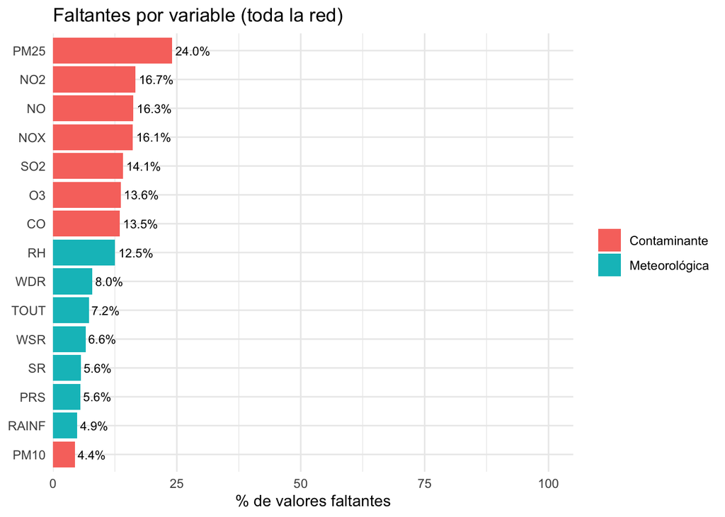

```r
na_var <- diccionario |>
  select(variable, grupo, pct_nulos) |>
  arrange(desc(pct_nulos))

ggplot(na_var, aes(reorder(variable, pct_nulos), pct_nulos, fill = grupo)) +
  geom_col() + coord_flip() +
  geom_text(aes(label = sprintf("%.1f%%", pct_nulos)), hjust = -.1, size = 3) +
  scale_y_continuous(limits = c(0, 100), expand = expansion(mult = c(0, .05))) +
  labs(x = NULL, y = "% de valores faltantes", fill = NULL,
       title = "Faltantes por variable (toda la red)")
```

**Código**

```r
cat("% total de celdas de medición vacías:",
    sprintf("%.1f%%", mean(is.na(as.matrix(datos[vars]))) * 100), "\n")
```

```
% total de celdas de medición vacías: 11.3%
```

### 3.1.2 Faltantes por estación, variable y año: ¿falla o “no se mide”?

El porcentaje global nos puede mostrar qu **no todas las estaciones miden todos los contaminantes**. Una estación con 100 % de nulos en NO2 durante un año probablemente *no tiene ese analizador*; es una ausencia **estructural**, no una falla. Este tipo de faltante no se puede ni se debe imputar con series de tiempo, porque no hay información observada de esa serie. En cambio, una estación con 15 % de nulos tiene fallas intermitentes, que sí son candidatas a imputación.

Se clasifica cada combinación *estación × variable × año* usando los umbrales de configuración:

| Clase | Regla |
| --- | --- |
| No medida | % NA ≥ 95 |
| Cobertura baja | 50 ≤ % NA < 95 |
| Utilizable | % NA < 50 |

**Código**

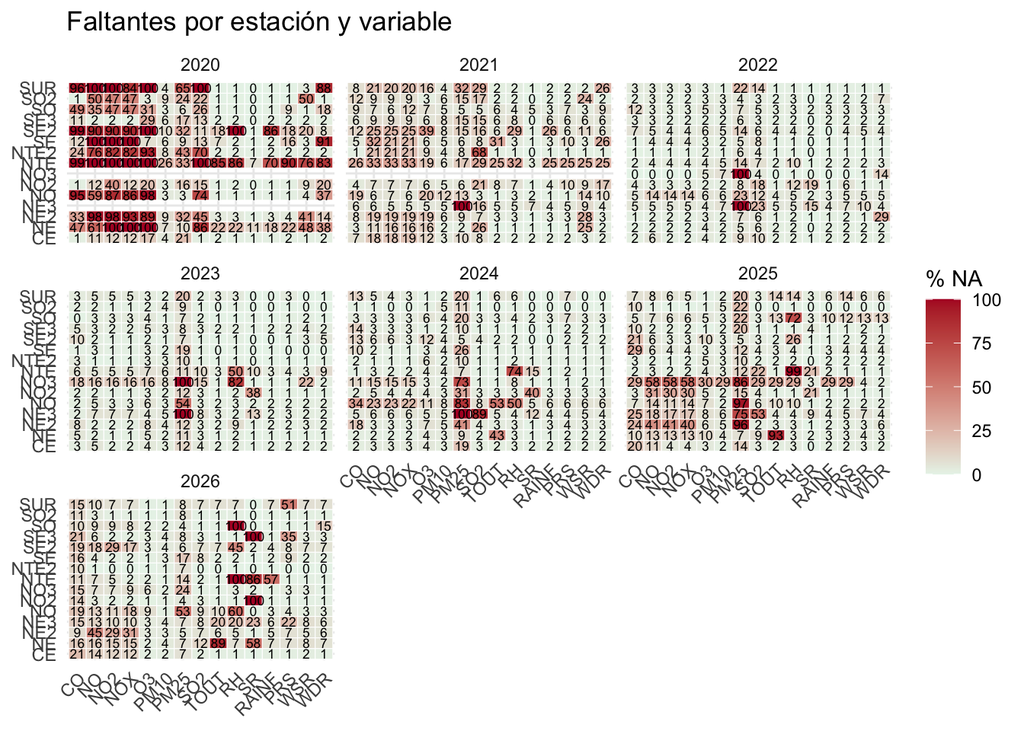

```r
cobertura <- map_dfr(vars, \(v) {
  datos |> group_by(estacion, anio) |>
    summarise(variable = v, pct_na = mean(is.na(.data[[v]])) * 100, .groups = "drop")
}) |>
  mutate(clase = case_when(pct_na >= umbral_estructural ~ "No medida",
                           pct_na >= umbral_cobertura   ~ "Cobertura baja",
                           TRUE                         ~ "Utilizable"),
         clase = factor(clase, c("Utilizable", "Cobertura baja", "No medida")),
         variable = factor(variable, vars))

ggplot(cobertura, aes(variable, estacion, fill = pct_na)) +
  geom_tile(color = "white") +
  geom_text(aes(label = round(pct_na)), size = 2.3) +
  scale_fill_gradient(low = "#e8f4ea", high = "#b2182b", limits = c(0, 100)) +
  facet_wrap(~anio) +
  labs(x = NULL, y = NULL, fill = "% NA",
       title = "Faltantes por estación y variable") +
  theme(axis.text.x = element_text(angle = 45, hjust = 1))
```

**Código**

```r
cobertura |> count(clase) |> mutate(pct = percent(n / sum(n), .1)) |>
  kable(caption = "Combinaciones estación × variable × año por clase de cobertura")
```

Combinaciones estación × variable × año por clase de cobertura

| clase | n | pct |
| --- | --- | --- |
| Utilizable | 1440 | 94.1% |
| Cobertura baja | 54 | 3.5% |
| No medida | 36 | 2.4% |

**Código**

```r
cobertura |> filter(clase == "No medida") |>
  arrange(estacion, variable) |>
  group_by(estacion, anio) |>
  summarise(variables_no_medidas = paste(variable, collapse = ", "), .groups = "drop") |>
  kable(caption = "Variables consideradas 'no medidas' por estación y año")
```

Variables consideradas ‘no medidas’ por estación y año

| estacion | anio | variables_no_medidas |
| --- | --- | --- |
| NE | 2020 | NO2, NOX, O3 |
| NE2 | 2020 | NO, NO2 |
| NE2 | 2025 | PM25 |
| NE3 | 2021 | PM25 |
| NE3 | 2022 | PM25 |
| NE3 | 2023 | PM25 |
| NE3 | 2024 | PM25 |
| NO | 2020 | O3 |
| NO | 2025 | PM25 |
| NO2 | 2026 | SR |
| NO3 | 2022 | PM25 |
| NO3 | 2023 | PM25 |
| NTE | 2020 | CO, NO, NO2, NOX, O3, SO2 |
| NTE | 2025 | RH |
| NTE | 2026 | RH |
| SE | 2020 | NO, NO2, NOX |
| SE2 | 2020 | CO, O3, RH |
| SE3 | 2026 | SR |
| SO | 2026 | RH |
| SUR | 2020 | CO, NO, NO2, O3, SO2 |

**Implicación para el modelado:** las 15 variables no están disponibles en las 13–15 estaciones. Para un análisis multivariado (PCA, análisis de factores, discriminante) se necesita un conjunto de variables observado *simultáneamente*; esto se retomará en la selección de datos, pero conviene tenerlo presente desde aquí: la estructura de faltantes condiciona **qué estaciones y qué variables** entran juntas al modelo.

### 3.1.3 ¿Cuándo faltan? Patrón temporal de los faltantes

Si los faltantes se concentran en ciertos meses u horas, no son aleatorios y una imputación ingenua sesga. Se resume el % de NA por mes, considerando solo series utilizables (se excluyen las “no medidas” para no inflar el patrón con ausencias estructurales).

**Código**

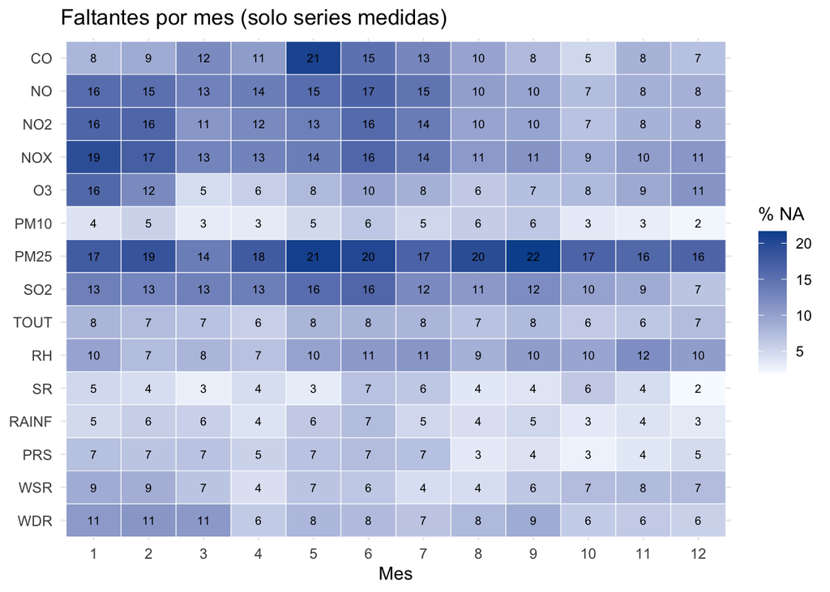

```r
utilizables <- cobertura |> filter(clase != "No medida") |> select(estacion, anio, variable)

na_mes <- map_dfr(vars, \(v) {
  datos |> select(estacion, anio, mes, x = all_of(v)) |>
    semi_join(utilizables |> filter(variable == v), by = c("estacion", "anio")) |>
    group_by(mes) |> summarise(variable = v, pct_na = mean(is.na(x)) * 100, .groups = "drop")
})

ggplot(na_mes, aes(factor(mes), factor(variable, rev(vars)), fill = pct_na)) +
  geom_tile(color = "white") +
  geom_text(aes(label = round(pct_na)), size = 2.5) +
  scale_fill_gradient(low = "#f7fbff", high = "#08519c") +
  labs(x = "Mes", y = NULL, fill = "% NA",
       title = "Faltantes por mes (solo series medidas)")
```

Si un mes tiene mucho más NA que otros (por ejemplo, por calibraciones, mantenimiento o fallas de comunicación concentradas), el mecanismo de datos faltantes no es completamente aleatorio (MCAR) sino, en el mejor caso, aleatorio condicionado a variables observadas (MAR) [@rubin1976]. Esto **no se puede demostrar con los datos**, solo se argumenta; por eso la estrategia de imputación se valida con enmascaramiento sintético (sección de imputación).

### 3.1.4 Longitud de los huecos

Lo que decide *cómo* imputar no es cuántos datos faltan, sino **cuán largos son los huecos consecutivos**. Un hueco de 2 horas se rellena con interpolación; uno de 3 semanas exige información de otras fuentes (otras estaciones, otras variables). Se calcula la longitud de cada racha de NA consecutivos en cada serie utilizable.

**Código**

```r
long_huecos <- function(x) { r <- rle(is.na(x)); r$lengths[r$values] }

huecos <- map_dfr(vars, \(v) {
  datos |> select(estacion, anio, x = all_of(v)) |>
    semi_join(utilizables |> filter(variable == v), by = c("estacion", "anio")) |>
    group_by(estacion, anio) |>
    summarise(l = list(long_huecos(x)), .groups = "drop") |>
    unnest(l) |> mutate(variable = v)
})

resumen_huecos <- huecos |>
  group_by(variable) |>
  summarise(n_huecos      = n(),
            horas_en_hueco= sum(l),
            mediana_h     = median(l),
            `% <= 6 h`    = mean(l <= huecos_cortos) * 100,
            `% 7-72 h`    = mean(l > huecos_cortos & l <= huecos_medios) * 100,
            `% > 72 h`    = mean(l > huecos_medios) * 100,
            `% de horas faltantes en huecos > 72 h` = sum(l[l > huecos_medios]) / sum(l) * 100,
            maximo_h      = max(l), .groups = "drop") |>
  arrange(match(variable, vars))
kable(resumen_huecos, digits = 1, format.args = list(big.mark = ","),
      caption = "Longitud de huecos por variable (solo series medidas)")
```

Longitud de huecos por variable (solo series medidas)

| variable | n_huecos | horas_en_hueco | mediana_h | % <= 6 h | % 7-72 h | % > 72 h | % de horas faltantes en huecos > 72 h | maximo_h |
| --- | --- | --- | --- | --- | --- | --- | --- | --- |
| CO | 5,241 | 86,173 | 1 | 82.5 | 14.8 | 2.7 | 74.5 | 7,190 |
| NO | 13,670 | 100,109 | 1 | 90.1 | 9.1 | 0.8 | 59.1 | 7,884 |
| NO2 | 8,849 | 94,700 | 1 | 88.8 | 10.1 | 1.2 | 69.4 | 7,884 |
| NOX | 8,793 | 107,645 | 1 | 88.0 | 10.7 | 1.3 | 73.0 | 7,884 |
| O3 | 8,921 | 69,617 | 1 | 89.8 | 9.3 | 0.9 | 62.0 | 5,113 |
| PM10 | 7,766 | 36,881 | 1 | 89.1 | 10.3 | 0.6 | 29.2 | 2,449 |
| PM25 | 24,491 | 138,137 | 1 | 92.0 | 7.3 | 0.7 | 50.7 | 6,377 |
| SO2 | 15,195 | 99,635 | 1 | 91.3 | 7.8 | 0.8 | 55.7 | 3,714 |
| TOUT | 5,114 | 60,204 | 1 | 87.4 | 11.5 | 1.0 | 70.8 | 5,902 |
| RH | 5,069 | 76,488 | 1 | 87.2 | 11.3 | 1.5 | 77.0 | 7,176 |
| SR | 3,163 | 36,634 | 1 | 72.5 | 26.2 | 1.3 | 50.0 | 2,930 |
| RAINF | 4,328 | 40,974 | 1 | 90.1 | 8.9 | 1.0 | 68.7 | 5,895 |
| PRS | 5,094 | 46,236 | 1 | 87.9 | 11.0 | 1.1 | 61.5 | 7,905 |
| WSR | 7,259 | 54,664 | 1 | 86.1 | 12.9 | 1.0 | 53.9 | 5,895 |
| WDR | 6,858 | 66,322 | 1 | 86.4 | 12.1 | 1.5 | 63.8 | 5,897 |

Se distinguen dos lecturas: la mayoría de los **huecos** son cortos (`% <= 6 h`), pero lo que pesa en **horas faltantes** son los pocos huecos muy largos (`% de horas faltantes en huecos > 72 h`). Esta doble mirada justifica una estrategia en **niveles** según la longitud del hueco.

**Código**

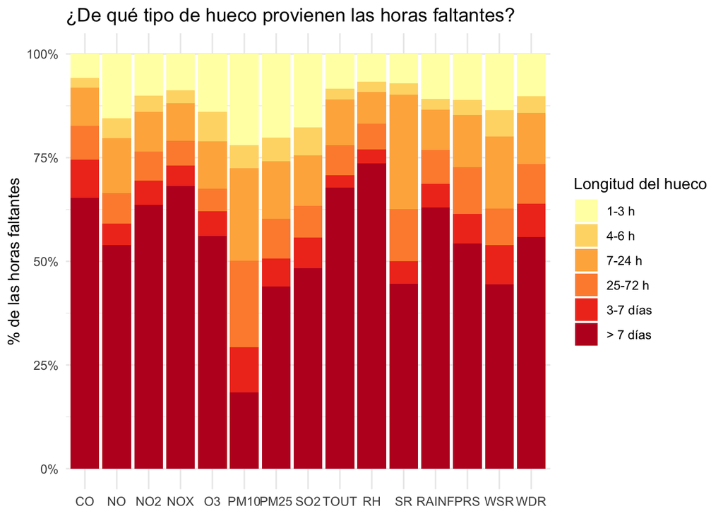

```r
huecos |>
  mutate(cat = cut(l, c(0, 3, 6, 24, 72, 168, Inf),
                   labels = c("1-3 h", "4-6 h", "7-24 h", "25-72 h", "3-7 días", "> 7 días")),
         variable = factor(variable, vars)) |>
  group_by(variable, cat) |> summarise(horas = sum(l), .groups = "drop") |>
  ggplot(aes(variable, horas, fill = cat)) +
  geom_col(position = "fill") +
  scale_y_continuous(labels = percent) +
  scale_fill_brewer(palette = "YlOrRd") +
  labs(x = NULL, y = "% de las horas faltantes", fill = "Longitud del hueco",
       title = "¿De qué tipo de hueco provienen las horas faltantes?")
```

## 3.2 Valores espurios o erróneos

### 3.2.1 Rangos de operación de SIMA

SIMA define, para cada año, el **rango de operación** (valores posibles de la medición) y el **rango del fabricante** (valores que puede medir el sensor). Un valor fuera del rango de operación se considera inválido según el protocolo de SIMA; uno fuera del rango del fabricante es *físicamente imposible* para ese sensor. Las notas del documento agregan reglas puntuales (por ejemplo, 2020: “omitir máximo de O3 en NTE2”, “no considerar WSR > 75 km/h”, “no considerar BP fuera de rango”), que quedan cubiertas al aplicar los rangos.

Se transcriben las tablas del documento (verificadas contra la imagen original) y se renombran las variables con los nombres de esta base (`WS`→`WSR`, `TEMP`→`TOUT`, `BP`→`PRS`, `WD`→`WDR`, `NOx`→`NOX`).

**Código**

```r
rangos_op <- tribble(
  ~anio, ~PM10, ~PM25, ~O3, ~NO, ~NO2, ~NOX, ~SO2, ~CO, ~RH, ~WSR, ~TOUT,  ~SR,   ~PRS,   ~WDR, ~RAINF,
  "2020","0,800","0,205.94","0,153","0,500","0,200","0,500","0,200","0,20","0,100","0,75","0,41","0,1","690,750","0,360","0,30",
  "2021","0,800","0,325","0,175","0,350","0,100","0,400","0,300","0,10","0,100","0,40","-6.5,45","0,1","690,740","0,360","0,80",
  "2022","0,999","0,450","0,160","0,400","0,175","0,420","0,200","0,8","0,100","0,35","-5,45","0,1.25","700,740","0,360","0,25",
  "2023","0,900","0,800","0,175","0,500","0,175","0,500","0,250","0,14","0,100","0,40","0,45","0,1","690,740","0,360","0,70",
  "2024","0,999","0,999","0,180","0,400","0,130","0,500","0,150","0,18","0,100","0,38","-4,45.5","0,1.26","687.5,740","0,360","0,50",
  "2025","0,820","0,350","0,185","0,350","0,175","0,400","0,405","0,10","0,100","0,40","-4.5,45","0,1.2","688,740","0,360","0,25",
  "2026","0,820","0,350","0,185","0,350","0,175","0,400","0,405","0,10","0,100","0,40","-4.5,45","0,1.2","688,740","0,360","0,25"
) |>
  pivot_longer(-anio, names_to = "variable", values_to = "rango") |>
  separate(rango, c("min", "max"), sep = ",(?=[^,]*$)", convert = TRUE) |>
  mutate(anio = as.integer(anio))

rangos_fab <- tribble(       # rango del fabricante (una sola fila para todos los años)
  ~variable, ~min_fab, ~max_fab,
  "PM10", 0, 1000, "PM25", 0, 1000, "O3", 0, 1000, "NO", 0, 500, "NO2", 0, 500,
  "NOX", 0, 500, "SO2", 0, 500, "CO", 0, 50, "RH", 0, 100, "WSR", 0, 180,
  "TOUT", -50, 50, "SR", 0, 1.4, "PRS", 449.9, 824.9, "WDR", 0, 360
)
rangos_op |> filter(anio == min(anio)) |> kable(caption = "Rangos de operación del primer año (ejemplo)")
```

Rangos de operación del primer año (ejemplo)

| anio | variable | min | max |
| --- | --- | --- | --- |
| 2020 | PM10 | 0 | 800.00 |
| 2020 | PM25 | 0 | 205.94 |
| 2020 | O3 | 0 | 153.00 |
| 2020 | NO | 0 | 500.00 |
| 2020 | NO2 | 0 | 200.00 |
| 2020 | NOX | 0 | 500.00 |
| 2020 | SO2 | 0 | 200.00 |
| 2020 | CO | 0 | 20.00 |
| 2020 | RH | 0 | 100.00 |
| 2020 | WSR | 0 | 75.00 |
| 2020 | TOUT | 0 | 41.00 |
| 2020 | SR | 0 | 1.00 |
| 2020 | PRS | 690 | 750.00 |
| 2020 | WDR | 0 | 360.00 |
| 2020 | RAINF | 0 | 30.00 |

La presión atmosférica depende de la altitud de cada estación, por lo que un rango único para toda la red no es adecuado. Para PRS se usa la mediana de cada estación como referencia y una tolerancia, además del rango del fabricante. El histograma sirve para elegir la tolerancia.

**Código**

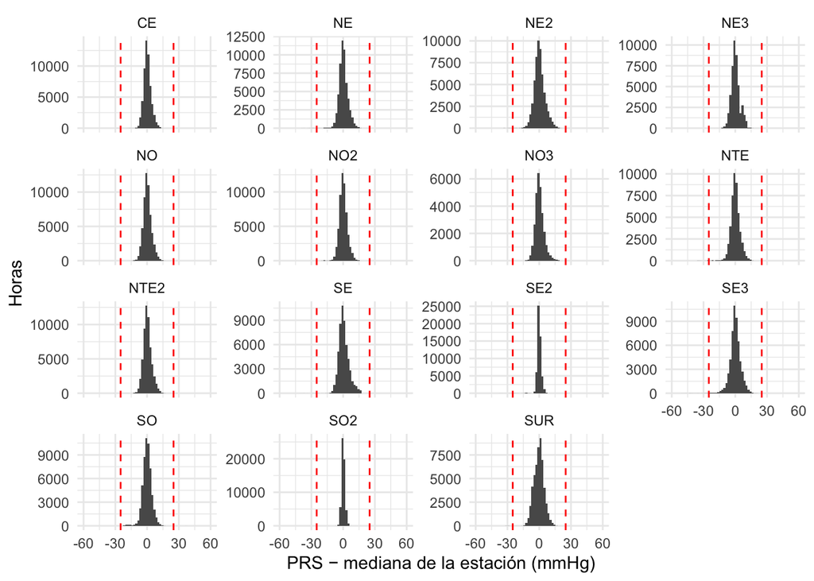

```r
tol_prs <- 25   # mmHg; ajustar según el histograma

prs_ref <- datos |>
  filter(!is.na(PRS), PRS >= 449.9, PRS <= 824.9) |>
  group_by(estacion) |>
  summarise(prs_mediana = median(PRS), .groups = "drop")

datos |>
  filter(!is.na(PRS), PRS >= 449.9) |>
  left_join(prs_ref, by = "estacion") |>
  ggplot(aes(PRS - prs_mediana)) +
  geom_histogram(bins = 100) +
  geom_vline(xintercept = c(-tol_prs, tol_prs), linetype = "dashed", color = "red") +
  facet_wrap(~estacion, scales = "free_y") +
  coord_cartesian(xlim = c(-60, 60)) +
  labs(x = "PRS − mediana de la estación (mmHg)", y = "Horas")
```

**Código**

```r
fuera_sima <- map_dfr(setdiff(vars, "PRS"), \(v) {
  datos |> select(estacion, fecha, anio, valor = all_of(v)) |>
    filter(!is.na(valor)) |>
    inner_join(rangos_op |> filter(variable == v), by = "anio") |>
    filter(valor < min | valor > max) |>
    mutate(variable = v, sentido = if_else(valor < min, "bajo el mínimo", "sobre el máximo"))
}) |>
  left_join(rangos_fab, by = "variable") |>
  mutate(imposible_fisico = !is.na(min_fab) & (valor < min_fab | valor > max_fab))

fuera_prs <- datos |> select(estacion, fecha, anio, valor = PRS) |>
  filter(!is.na(valor)) |>
  left_join(prs_ref, by = "estacion") |>
  filter(valor < 449.9 | valor > 824.9 | abs(valor - prs_mediana) > tol_prs) |>
  transmute(estacion, fecha, anio, valor, variable = "PRS",
            sentido = if_else(valor < prs_mediana, "bajo el mínimo", "sobre el máximo"),
            min_fab = 449.9, max_fab = 824.9,
            imposible_fisico = valor < 449.9 | valor > 824.9)

fuera <- bind_rows(fuera_sima, fuera_prs)

fuera |>
  group_by(variable, sentido) |>
  summarise(n = n(), imposibles_para_el_sensor = sum(imposible_fisico),
            min_obs = min(valor), max_obs = max(valor), .groups = "drop") |>
  left_join(estad |> select(variable, n_obs), by = "variable") |>
  mutate(`% de observados` = n / n_obs * 100) |>
  select(-n_obs) |>
  kable(digits = 2, caption = "Valores fuera del rango de operación de SIMA")
```

Valores fuera del rango de operación de SIMA

| variable | sentido | n | imposibles_para_el_sensor | min_obs | max_obs | % de observados |
| --- | --- | --- | --- | --- | --- | --- |
| CO | sobre el máximo | 24 | 0 | 10.11 | 37.0 | 0.00 |
| NO | sobre el máximo | 285 | 11 | 350.50 | 945.1 | 0.04 |
| NOX | sobre el máximo | 226 | 28 | 400.20 | 971.8 | 0.03 |
| O3 | sobre el máximo | 7 | 0 | 159.00 | 265.0 | 0.00 |
| PM10 | sobre el máximo | 3 | 1 | 1000.00 | 1001.0 | 0.00 |
| PRS | bajo el mínimo | 302 | 2 | 0.00 | 705.4 | 0.04 |
| PRS | sobre el máximo | 3 | 0 | 738.90 | 738.9 | 0.00 |
| RAINF | sobre el máximo | 36 | 0 | 25.40 | 360.0 | 0.00 |
| RH | sobre el máximo | 292 | 292 | 101.00 | 725.0 | 0.04 |
| SO2 | sobre el máximo | 1 | 0 | 150.10 | 150.1 | 0.00 |
| SR | bajo el mínimo | 270 | 270 | -0.01 | 0.0 | 0.03 |
| SR | sobre el máximo | 921 | 826 | 1.00 | 604.0 | 0.12 |
| TOUT | bajo el mínimo | 512 | 401 | -67.49 | -0.1 | 0.07 |
| TOUT | sobre el máximo | 5 | 3 | 45.01 | 785.0 | 0.00 |
| WSR | sobre el máximo | 1704 | 40 | 35.30 | 337.0 | 0.22 |

**Código**

```r
fuera |> count(variable, estacion, name = "n") |> arrange(desc(n)) |>
  kable(caption = "¿Dónde se concentran los valores fuera de rango?")
```

¿Dónde se concentran los valores fuera de rango?

| variable | estacion | n |
| --- | --- | --- |
| WSR | SO2 | 973 |
| SR | NTE | 608 |
| TOUT | NTE | 427 |
| WSR | NO3 | 410 |
| WSR | NE2 | 282 |
| RH | NO | 263 |
| SR | SO | 246 |
| NO | SO | 220 |
| NOX | SO | 159 |
| SR | SO2 | 115 |
| SR | NE3 | 93 |
| PRS | SE3 | 92 |
| NOX | NO | 60 |
| PRS | NTE | 52 |
| NO | NO | 47 |
| PRS | NE | 46 |
| TOUT | SE | 35 |
| PRS | NE2 | 34 |
| SR | NE | 34 |
| SR | NO2 | 30 |
| SR | CE | 26 |
| TOUT | SUR | 26 |
| PRS | SE2 | 23 |
| RAINF | NTE | 23 |
| SR | NO3 | 23 |
| PRS | SE | 19 |
| PRS | SUR | 19 |
| TOUT | NE | 19 |
| WSR | NO | 16 |
| NO | NE2 | 15 |
| CO | SO | 13 |
| PRS | CE | 12 |
| RH | NO3 | 12 |
| SR | NO | 10 |
| RH | SE2 | 9 |
| NOX | NE2 | 7 |
| WSR | SO | 7 |
| TOUT | SO | 6 |
| WSR | NE | 6 |
| RAINF | SE2 | 5 |
| CO | NE3 | 4 |
| PRS | NTE2 | 4 |
| RAINF | NE3 | 4 |
| RH | NE2 | 4 |
| RH | NTE | 4 |
| WSR | NO2 | 4 |
| CO | SE | 3 |
| O3 | SE2 | 3 |
| SR | NE2 | 3 |
| NO | SE2 | 2 |
| PM10 | NE | 2 |
| RAINF | CE | 2 |
| SR | SE3 | 2 |
| TOUT | NE2 | 2 |
| TOUT | NO | 2 |
| WSR | CE | 2 |
| WSR | SE3 | 2 |
| CO | CE | 1 |
| CO | NE | 1 |
| CO | NO2 | 1 |
| CO | NTE2 | 1 |
| NO | SO2 | 1 |
| O3 | NE3 | 1 |
| O3 | NO2 | 1 |
| O3 | NTE2 | 1 |
| O3 | SO | 1 |
| PM10 | NTE | 1 |
| PRS | NE3 | 1 |
| PRS | NO | 1 |
| PRS | SO | 1 |
| PRS | SO2 | 1 |
| RAINF | NE2 | 1 |
| RAINF | SUR | 1 |
| SO2 | SE3 | 1 |
| SR | SE | 1 |
| WSR | NE3 | 1 |
| WSR | SUR | 1 |

### 3.2.2 Consistencia física entre variables

Algunas relaciones entre variables deben cumplirse siempre; su violación revela errores que un rango univariado no detecta:

- `PM2.5 ≤ PM10` (las partículas finas son un subconjunto de las gruesas). Es el mismo criterio de consistencia que usan las autoras y autores del modelo de imputación MIMA.
- `NOX ≈ NO + NO2` (así lo define el archivo de etiquetas). Se admite una tolerancia de 1 ppb por redondeo y por el hecho de que los tres se miden como promedio horario.

**Código**

```r
pm <- datos |> filter(!is.na(PM10), !is.na(PM25))
nox <- datos |> filter(!is.na(NO), !is.na(NO2), !is.na(NOX)) |>
  mutate(dif = NOX - (NO + NO2))

bind_rows(
  tibble(regla = "PM2.5 <= PM10", evaluables = nrow(pm),
         violaciones = sum(pm$PM25 > pm$PM10)),
  tibble(regla = "|NOX - (NO + NO2)| <= 1 ppb", evaluables = nrow(nox),
         violaciones = sum(abs(nox$dif) > 1))
) |> mutate(`% violaciones` = violaciones / evaluables * 100) |>
  kable(digits = 2, format.args = list(big.mark = ","), caption = "Reglas de consistencia física")
```

Reglas de consistencia física

| regla | evaluables | violaciones | % violaciones |
| --- | --- | --- | --- |
| PM2.5 <= PM10 | 621,540 | 37 | 0.01 |
| \|NOX - (NO + NO2)\| <= 1 ppb | 679,781 | 29,395 | 4.32 |

**Código**

```r
nox |> filter(abs(dif) > 1) |> count(estacion, name = "violaciones NOX") |>
  arrange(desc(`violaciones NOX`)) |> kable(caption = "Violaciones NOX ≈ NO + NO2 por estación")
```

Violaciones NOX ≈ NO + NO2 por estación

| estacion | violaciones NOX |
| --- | --- |
| NE3 | 20262 |
| NTE2 | 4761 |
| NE2 | 1685 |
| CE | 926 |
| NO | 479 |
| SE2 | 279 |
| NTE | 273 |
| SO | 171 |
| SE3 | 161 |
| NO2 | 141 |
| SE | 116 |
| SO2 | 59 |
| NE | 36 |
| NO3 | 25 |
| SUR | 21 |

### 3.2.3 Valores repetidos, límite de detección y saturación

Tres rasgos típicos de datos de analizadores automáticos que pueden confundirse con datos válidos:

1. **Rachas de valores idénticos** (sensor “congelado”). SIMA tiene una bandera para esto (`s`), pero conviene verificar si quedaron valores sin marcar. En `RAINF` y `SR` los ceros repetidos son normales (no llueve; es de noche), y en `NO`, `NO2` y `NOX` hay un piso de detección; por eso se excluyen de esta revisión.
2. **Límite de detección:** cuando la concentración está por debajo de lo que el analizador puede medir se reporta un valor mínimo fijo. Si muchas observaciones valen exactamente el mínimo, la variable está *censurada por la izquierda*, lo que afecta la normalidad y las transformaciones logarítmicas posteriores.
3. **Saturación:** el analizador topa en su máximo (500 ppb en NO/NOX).

**Código**

```r
racha_larga <- function(x, k) {
  g <- cumsum(c(TRUE, diff(x) != 0 | is.na(diff(x))))
  n <- ave(seq_along(x), g, FUN = length)
  !is.na(x) & n >= k
}
k_rep <- 12   # horas iguales consecutivas para considerar sospechoso
vars_rep <- c("CO","O3","PM10","PM25","SO2","TOUT","RH","PRS","WSR","WDR")

repetidos <- map_dfr(vars_rep, \(v) {
  datos |> arrange(estacion, fecha) |> group_by(estacion) |>
    summarise(variable = v, n = sum(racha_larga(.data[[v]], k_rep)), .groups = "drop")
}) |> filter(n > 0)

repetidos |> group_by(variable) |>
  summarise(observaciones_en_rachas = sum(n), estaciones = n_distinct(estacion),
            estacion_mayor = estacion[which.max(n)], .groups = "drop") |>
  kable(caption = sprintf("Observaciones en rachas de >= %d horas idénticas", k_rep))
```

Observaciones en rachas de >= 12 horas idénticas

| variable | observaciones_en_rachas | estaciones | estacion_mayor |
| --- | --- | --- | --- |
| CO | 510 | 5 | NE2 |
| O3 | 14 | 1 | NO |
| PM10 | 113 | 3 | NTE2 |
| PM25 | 166 | 3 | NTE2 |
| PRS | 2181 | 2 | NE3 |
| SO2 | 73 | 1 | NE3 |
| WSR | 29 | 1 | NTE |

**Código**

```r
# Límite de detección y saturación
tibble(
  variable = c("NO", "NOX", "NO2", "SO2", "CO", "PM25"),
  minimo   = map_dbl(variable, \(v) min(datos[[v]], na.rm = TRUE)),
  `% de observados = mínimo` = map_dbl(variable, \(v) mean(datos[[v]] == min(datos[[v]], na.rm = TRUE), na.rm = TRUE) * 100)
) |> kable(digits = 2, caption = "Piso de detección: proporción de observaciones iguales al mínimo")
```

Piso de detección: proporción de observaciones iguales al mínimo

| variable | minimo | % de observados = mínimo |
| --- | --- | --- |
| NO | 0.3 | 0.00 |
| NOX | 0.5 | 0.46 |
| NO2 | 0.0 | 0.04 |
| SO2 | 0.0 | 0.00 |
| CO | 0.0 | 0.00 |
| PM25 | 0.0 | 0.00 |

**Código**

```r
cat("Observaciones de NO en el tope de 500 ppb:", sum(datos$NO == 500, na.rm = TRUE),
    "| NOX:", sum(datos$NOX == 500, na.rm = TRUE), "\n")
```

```
Observaciones de NO en el tope de 500 ppb: 42 | NOX: 43
```

# 4 Imputación de datos faltantes

Antes de imputar, se decide qué método usa cada contaminante. PM2.5, PM10 y NO2 usan los métodos de la literatura del Tec. Los contaminantes restantes se asignan al método del más correlacionado, siguiendo la idea de la “partícula más parecida”.

## 4.1 Preparar la base para imputar

Este paso convierte a NA los valores fuera del rango de operación de SIMA (tabla fuera, ya calculada en la sección de calidad de datos).

**Código**

```r
datos$llave <- paste(datos$estacion, as.numeric(datos$fecha))
datos_lim <- datos
for (v in vars) {
  llaves_malas <- paste(fuera$estacion[fuera$variable == v], as.numeric(fuera$fecha[fuera$variable == v]))
  datos_lim[[v]][datos_lim$llave %in% llaves_malas] <- NA_real_
}
datos_lim$llave <- NULL
dim(datos_lim)
```

```
[1] 831095     20
```

**Código**

```r
names(datos_lim)
```

```
 [1] "estacion" "fecha"    "anio"     "CO"       "NO"       "NO2"
 [7] "NOX"      "O3"       "PM10"     "PM25"     "PRS"      "RAINF"
[13] "RH"       "SO2"      "SR"       "TOUT"     "WSR"      "WDR"
[19] "mes"      "hora"
```

**Código**

```r
# o también:
colnames(datos_lim)
```

```
 [1] "estacion" "fecha"    "anio"     "CO"       "NO"       "NO2"
 [7] "NOX"      "O3"       "PM10"     "PM25"     "PRS"      "RAINF"
[13] "RH"       "SO2"      "SR"       "TOUT"     "WSR"      "WDR"
[19] "mes"      "hora"
```

## 4.2 Marcar qué NO se debe imputar

Si una estación no mide un contaminante (por ejemplo NO2 en NTE), esa serie está vacía casi todo el año por diseño, no por falla. Esas combinaciones estación-variable-año se guardan en no_medida para no fabricarles datos.

**Código**

```r
umbral_estructural <- 95   # % de NA anual desde el cual se considera "no medida"

no_medida <- map_dfr(vars, \(v) {
  datos_lim |> group_by(estacion, anio) |>
    summarise(pct_na = mean(is.na(.data[[v]])) * 100, .groups = "drop") |>
    filter(pct_na >= umbral_estructural) |> mutate(variable = v)
}) |> transmute(estacion = as.character(estacion), anio, variable)

nrow(no_medida)
```

```
[1] 36
```

## 4.3 Catálogo de coordenadas de las estaciones

Necesario para el método espacial (B). clave es el código de la estación tal como aparece en datos_lim$estacion.

**Código**

```r
dms <- function(s) {   # convierte "25°39'55''N" a grados decimales
  p <- as.numeric(str_extract_all(s, "[0-9]+")[[1]])
  signo <- if (str_detect(s, "[SW]")) -1 else 1
  signo * (p[1] + p[2]/60 + p[3]/3600)
}
catalogo <- tribble(
  ~clave, ~lat_dms, ~lon_dms,
  "SE","25°39'55''N","100°14'37''W", "NE","25°44'41''N","100°15'11''W", "CE","25°40'33''N","100°20'18''W",
  "NO","25°45'46''N","100°22'09''W", "SO","25°40'32''N","100°27'29''W", "NO2","25°48'01''N","100°35'04''W",
  "NTE","25°47'55''N","100°19'38''W", "NE2","25°46'38''N","100°11'17''W", "SE2","25°38'45''N","100°05'43''W",
  "SO2","25°39'54''N","100°24'46''W", "SE3","25°36'04''N","99°59'57''W", "SUR","25°37'01''N","100°16'26''W",
  "NTE2","25°43'47''N","100°18'36''W", "NE3","25°47'26''N","100°04'42''W", "NO3","25°46'06''N","100°27'49''W"
) |> mutate(lat = map_dbl(lat_dms, dms), lon = map_dbl(lon_dms, dms)) |> select(clave, lat, lon)
catalogo
```

| clave | lat | lon |
| --- | --- | --- |
| SE | 25.66528 | -100.24361 |
| NE | 25.74472 | -100.25306 |
| CE | 25.67583 | -100.33833 |
| NO | 25.76278 | -100.36917 |
| SO | 25.67556 | -100.45806 |
| NO2 | 25.80028 | -100.58444 |
| NTE | 25.79861 | -100.32722 |
| NE2 | 25.77722 | -100.18806 |
| SE2 | 25.64583 | -100.09528 |
| SO2 | 25.66500 | -100.41278 |

[output cut: 5 more lines]

## 4.4 Asignar el método a cada contaminante

**Código**

```r
tabla_metodo <- tibble(variable = c("PM25", "PM10", "NO2"),
                       metodo   = c("A_mvn24", "C_fpca", "B_espacial"))
otros <- c("CO", "O3", "NOX", "SO2", "NO")

corr_contaminantes <- datos_lim |> select(all_of(c(tabla_metodo$variable, otros))) |>
  cor(use = "pairwise.complete.obs")

asignados <- tibble(
  variable = otros,
  parecido = map_chr(otros, \(v) tabla_metodo$variable[which.max(abs(corr_contaminantes[v, tabla_metodo$variable]))])
) |> left_join(tabla_metodo, by = c(parecido = "variable"))

tabla_metodo <- bind_rows(tabla_metodo, asignados |> select(variable, metodo))
tabla_metodo |> kable(caption = "Método asignado a cada contaminante")
```

Método asignado a cada contaminante

| variable | metodo |
| --- | --- |
| PM25 | A_mvn24 |
| PM10 | C_fpca |
| NO2 | B_espacial |
| CO | A_mvn24 |
| O3 | B_espacial |
| NOX | B_espacial |
| SO2 | A_mvn24 |
| NO | B_espacial |

## 4.5 Método A - Normal 24-variada por día de la semana (PM2.5)

Por estación y día de la semana se arma una matriz días×24 horas. La media y covarianza se estiman solo con días completos, y la covarianza se regulariza por shrinkage (λ=0.2) porque hay 24 variables (horas) y pocos días completos. Un día con huecos se imputa con la media condicional dado lo observado.

**Código**

```r
cov_shrink <- function(S, lambda = 0.2) lambda * diag(diag(S)) + (1 - lambda) * S

ajustar_mvn_dia <- function(datos, v, estacion_sel, lambda = 0.2, min_dias_completos = 15) {
  d <- datos |> filter(estacion == estacion_sel) |>
    mutate(dia = as_date(fecha), hora = hour(fecha)) |> select(dia, hora, x = all_of(v))
  W <- d |> pivot_wider(names_from = hora, values_from = x) |> arrange(dia)
  M <- as.matrix(W[, -1]); dow <- wday(as_date(W$dia), week_start = 1)
  modelos <- map(1:7, \(j) {
    completos <- M[dow == j, , drop = FALSE] |> (\(x) x[complete.cases(x), , drop = FALSE])()
    if (nrow(completos) < min_dias_completos) return(NULL)
    list(mu = colMeans(completos), S = cov_shrink(cov(completos), lambda))
  })
  list(M = M, dow = dow, fechas = as_date(W$dia), modelos = modelos)
}

imputar_mvn_dia <- function(ajuste, max_faltantes_dia = 18) {
  M <- ajuste$M
  for (i in seq_len(nrow(M))) {
    mod <- ajuste$modelos[[ajuste$dow[i]]]
    x <- M[i, ]; faltan <- which(is.na(x)); obs <- which(!is.na(x))
    if (!length(faltan) || is.null(mod) || !length(obs) || length(faltan) > max_faltantes_dia) next
    b <- tryCatch(mod$S[faltan, obs, drop = FALSE] %*% solve(mod$S[obs, obs, drop = FALSE], x[obs] - mod$mu[obs]),
                  error = \(e) NULL)
    if (!is.null(b)) M[i, faltan] <- mod$mu[faltan] + as.numeric(b)
  }
  M
}
```

Se aplica a todas las estaciones y se reensambla en formato largo (una fila por hora):

**Código**

```r
aplicar_metodoA <- function(v) {
  map_dfr(levels(datos_lim$estacion), \(est) {
    aj <- ajustar_mvn_dia(datos_lim, v, est)
    if (all(map_lgl(aj$modelos, is.null))) return(NULL)   # sin días completos: no se puede estimar
    M <- imputar_mvn_dia(aj)
    tibble(fecha = as_datetime(aj$fechas)) |>
      slice(rep(seq_len(n()), each = 24)) |>
      mutate(hora = rep(0:23, times = length(aj$fechas)), fecha = fecha + hours(hora),
             estacion = est, valor = as.vector(t(M)), variable = v) |>
      select(-hora)
  })
}
vars_metodoA <- tabla_metodo$variable[tabla_metodo$metodo == "A_mvn24"]
imp_A <- map_dfr(vars_metodoA, aplicar_metodoA)
cat("Filas:", nrow(imp_A), "| % aún sin imputar:", round(mean(is.na(imp_A$valor)) * 100, 1), "\n")
```

```
Filas: 2493288 | % aún sin imputar: 12.8
```

## 4.6 Método B — interpolación espacial IDW y spline (NO2)

**Código**

```r
idw_hora <- function(obs, xy_falt, p_pot = 2) {
  d <- sqrt(outer(xy_falt[,1], obs$lon, "-")^2 + outer(xy_falt[,2], obs$lat, "-")^2)
  d[d == 0] <- 1e-6; w <- 1 / d^p_pot
  as.numeric((w %*% obs$valor) / rowSums(w))
}
spline_hora <- function(obs, xy_falt) {
  if (nrow(obs) < 4) return(rep(NA_real_, nrow(xy_falt)))
  m <- tryCatch(mgcv::gam(valor ~ s(lon, lat, k = min(nrow(obs) - 1, 6)), data = obs), error = \(e) NULL)
  if (is.null(m)) return(rep(NA_real_, nrow(xy_falt)))
  as.numeric(predict(m, newdata = data.frame(lon = xy_falt[,1], lat = xy_falt[,2])))
}
ioa <- function(e, o) 1 - sum((e - o)^2) / sum((abs(e - mean(o)) + abs(o - mean(o)))^2)

validar_espacial <- function(datos, v, xy, n_muestra = 300, seed = 2026) {
  W <- datos |> select(fecha, estacion, x = all_of(v)) |> pivot_wider(names_from = estacion, values_from = x)
  ests <- intersect(colnames(W)[-1], xy$clave); Wm <- as.matrix(W[, ests])
  candidatas <- which(rowSums(!is.na(Wm)) >= 4)
  set.seed(seed); candidatas <- sample(candidatas, min(n_muestra, length(candidatas)))
  res <- map_dfr(candidatas, \(i) {
    fila <- Wm[i, ]; presentes <- which(!is.na(fila)); j <- sample(presentes, 1)
    obs <- tibble(clave = ests[setdiff(presentes, j)], valor = fila[setdiff(presentes, j)]) |> left_join(xy, by = "clave")
    falt_xy <- as.matrix(xy[xy$clave == ests[j], c("lon","lat")])
    tibble(idw = idw_hora(obs, falt_xy), spl = spline_hora(obs, falt_xy), verdad = fila[j])
  })
  s <- sd(Wm, na.rm = TRUE)
  tibble(metodo = c("idw","spline"),
    nmae = c(mean(abs(res$idw - res$verdad), na.rm = TRUE), mean(abs(res$spl - res$verdad), na.rm = TRUE)) / s,
    ioa = c(ioa(res$idw, res$verdad), ioa(res$spl[!is.na(res$spl)], res$verdad[!is.na(res$spl)])))
}
imputar_espacial <- function(datos, v, xy) {
  W <- datos |> select(fecha, estacion, x = all_of(v)) |> pivot_wider(names_from = estacion, values_from = x) |> arrange(fecha)
  ests <- intersect(colnames(W)[-1], xy$clave); M <- as.matrix(W[, ests])
  val <- validar_espacial(datos, v, xy); metodo_ganador <- val$metodo[which.min(val$nmae)]
  f_metodo <- if (metodo_ganador == "idw") idw_hora else spline_hora
  for (i in seq_len(nrow(M))) {
    fila <- M[i, ]; faltan <- which(is.na(fila)); presentes <- which(!is.na(fila))
    if (!length(faltan) || length(presentes) < 4) next
    obs <- tibble(clave = ests[presentes], valor = fila[presentes]) |> left_join(xy, by = "clave")
    M[i, faltan] <- f_metodo(obs, as.matrix(xy[match(ests[faltan], xy$clave), c("lon","lat")]))
  }
  list(fecha = W$fecha, estaciones = ests, M = M, validacion = val, metodo_ganador = metodo_ganador)
}
```

**Código**

```r
vars_metodoB <- tabla_metodo$variable[tabla_metodo$metodo == "B_espacial"]
resultados_B <- map(vars_metodoB, \(v) imputar_espacial(datos_lim, v, catalogo))
names(resultados_B) <- vars_metodoB

map_dfr(resultados_B, \(r) r$validacion, .id = "variable") |>
  kable(digits = 3, caption = "Validación espacial (IOA, nMAE) por contaminante")
```

Validación espacial (IOA, nMAE) por contaminante

| variable | metodo | nmae | ioa |
| --- | --- | --- | --- |
| NO2 | idw | 0.594 | 0.781 |
| NO2 | spline | 0.634 | 0.774 |
| O3 | idw | 0.338 | 0.921 |
| O3 | spline | 0.432 | 0.859 |
| NOX | idw | 0.457 | 0.712 |
| NOX | spline | 0.585 | 0.525 |
| NO | idw | 0.385 | 0.596 |
| NO | spline | 0.529 | 0.474 |

**Código**

```r
imp_B <- map_dfr(names(resultados_B), \(v) {
  r <- resultados_B[[v]]; colnames(r$M) <- r$estaciones
  as_tibble(r$M) |> mutate(fecha = r$fecha) |>
    pivot_longer(-fecha, names_to = "estacion", values_to = "valor") |> mutate(variable = v)
})
cat("Filas:", nrow(imp_B), "| % aún sin imputar:", round(mean(is.na(imp_B$valor)) * 100, 1), "\n")
```

```
Filas: 3461760 | % aún sin imputar: 1.9
```

## 4.7 Método C — FPCA / Karhunen-Loève por día (PM10)

Cada día se trata como una curva de 24 horas. Se calcula la curva media, la covarianza entre horas, y se retienen los componentes principales funcionales que explican el 90% de la varianza. Un día con huecos se reconstruye con la esperanza condicional de los scores.

**Código**

```r
ajustar_fpca_dia <- function(datos, v, estacion_sel, tau = 0.9, min_pct_obs = 5) {
  d <- datos |> filter(estacion == estacion_sel) |> mutate(dia = as_date(fecha), hora = hour(fecha))
  W <- d |> select(dia, hora, x = all_of(v)) |> pivot_wider(names_from = hora, values_from = x) |> arrange(dia)
  M <- as.matrix(W[, -1])
  if (mean(!is.na(M)) * 100 < min_pct_obs) return(NULL)   # muy poca información en esta estación
  mu <- colMeans(M, na.rm = TRUE)
  G <- cov(M, use = "pairwise.complete.obs")
  if (anyNA(G)) return(NULL)   # algunas horas nunca coinciden observadas
  ev <- eigen(G, symmetric = TRUE)
  L <- max(1, min(which(cumsum(ev$values) / sum(ev$values) >= tau)))
  sigma2 <- max(mean(ev$values[(L + 1):length(ev$values)]), 1e-6)
  list(M = M, fechas = as_date(W$dia), mu = mu, phi = ev$vectors[, 1:L, drop = FALSE], lambda = ev$values[1:L], sigma2 = sigma2)
}

imputar_fpca_dia <- function(ajuste, max_faltantes_dia = 18) {
  M <- ajuste$M; mu <- ajuste$mu; phi <- ajuste$phi; lambda <- ajuste$lambda; s2 <- ajuste$sigma2
  for (i in seq_len(nrow(M))) {
    x <- M[i, ]; faltan <- which(is.na(x)); obs <- which(!is.na(x))
    if (!length(faltan) || length(obs) < 3 || length(faltan) > max_faltantes_dia) next
    phi_obs <- phi[obs, , drop = FALSE]
    Sigma_Yi <- phi_obs %*% diag(lambda, length(lambda)) %*% t(phi_obs) + diag(s2, length(obs))
    xi <- tryCatch(diag(lambda, length(lambda)) %*% t(phi_obs) %*% solve(Sigma_Yi, x[obs] - mu[obs]), error = \(e) NULL)
    if (!is.null(xi)) M[i, faltan] <- mu[faltan] + as.numeric(phi[faltan, , drop = FALSE] %*% xi)
  }
  M
}
```

**Código**

```r
aplicar_metodoC <- function(v) {
  map_dfr(levels(datos_lim$estacion), \(est) {
    aj <- ajustar_fpca_dia(datos_lim, v, est)
    if (is.null(aj)) return(NULL)   # esta estación no tiene datos suficientes de esta variable
    M <- imputar_fpca_dia(aj)
    tibble(fecha = as_datetime(aj$fechas)) |> slice(rep(seq_len(n()), each = 24)) |>
      mutate(hora = rep(0:23, times = length(aj$fechas)), fecha = fecha + hours(hora),
             estacion = est, valor = as.vector(t(M)), variable = v) |> select(-hora)
  })
}
vars_metodoC <- tabla_metodo$variable[tabla_metodo$metodo == "C_fpca"]
imp_C <- map_dfr(vars_metodoC, aplicar_metodoC)
cat("Filas:", nrow(imp_C), "| % aún sin imputar:", round(mean(is.na(imp_C$valor)) * 100, 1), "\n")
```

```
Filas: 831096 | % aún sin imputar: 1.9
```

## 4.8 Juntar los tres métodos y restaurar lo “no medido”

**Código**

```r
imp_especifico <- bind_rows(imp_A, imp_B, imp_C)

for (i in seq_len(nrow(no_medida))) {
  imp_especifico$valor[imp_especifico$estacion == no_medida$estacion[i] &
                        imp_especifico$variable == no_medida$variable[i] &
                        year(imp_especifico$fecha) == no_medida$anio[i]] <- NA
}

imp_especifico |> group_by(variable) |>
  summarise(filas = n(), `% aún sin imputar` = round(mean(is.na(valor)) * 100, 1)) |>
  kable(caption = "Resultado de los métodos A/B/C, antes del respaldo por niveles")
```

Resultado de los métodos A/B/C, antes del respaldo por niveles

| variable | filas | % aún sin imputar |
| --- | --- | --- |
| CO | 831096 | 11.5 |
| NO | 865440 | 4.8 |
| NO2 | 865440 | 7.7 |
| NOX | 865440 | 4.1 |
| O3 | 865440 | 5.5 |
| PM10 | 831096 | 1.9 |
| PM25 | 831096 | 17.3 |
| SO2 | 831096 | 9.7 |

## 4.9 Respaldo por niveles para el residuo

**Código**

```r
lim_var <- function(v) switch(v, RH = c(0, 100), TOUT = c(-Inf, Inf), PRS = c(-Inf, Inf), c(0, Inf))

nivel_temporal <- function(x, v, corto = 6, medio = 72) {
  lim <- lim_var(v); cl <- \(z) pmin(pmax(z, lim[1]), lim[2])
  if (sum(!is.na(x)) < 48) return(x)   # muy pocos datos para estimar ciclo diario
  y1 <- cl(na_interpolation(x, option = "linear", maxgap = corto))
  y2 <- tryCatch(cl(as.numeric(na_seadec(ts(y1, frequency = 24), algorithm = "interpolation", maxgap = medio))),
                 error = \(e) y1)
  y2
}

aplicar_respaldo <- function(v, metodo_espacial_fijo = NULL) {
  base <- imp_especifico |> filter(variable == v) |> select(fecha, estacion, valor)
  # Niveles 1 y 2: temporal, por estación
  W <- base |> pivot_wider(names_from = estacion, values_from = valor) |> arrange(fecha)
  for (e in setdiff(colnames(W), "fecha")) W[[e]] <- nivel_temporal(W[[e]], v)
  base_t <- W |> pivot_longer(-fecha, names_to = "estacion", values_to = "valor")
  if (!any(is.na(base_t$valor))) return(base_t |> mutate(variable = v, metodo_espacial = NA_character_))

  # Nivel 3: espacial, sobre lo que aún falte (reutiliza idw_hora/spline_hora del Paso 6)
  metodo <- metodo_espacial_fijo
  if (is.null(metodo) || is.na(metodo)) {
    val <- validar_espacial(base_t |> rename(!!v := valor), v, catalogo)
    metodo <- val$metodo[which.min(val$nmae)]
  }
  f_metodo <- if (metodo == "idw") idw_hora else spline_hora
  Wr <- base_t |> pivot_wider(names_from = estacion, values_from = valor) |> arrange(fecha)
  ests <- intersect(colnames(Wr)[-1], catalogo$clave); M <- as.matrix(Wr[, ests])
  for (i in seq_len(nrow(M))) {
    fila <- M[i, ]; faltan <- which(is.na(fila)); presentes <- which(!is.na(fila))
    if (!length(faltan) || length(presentes) < 4) next
    obs <- tibble(clave = ests[presentes], valor = fila[presentes]) |> left_join(catalogo, by = "clave")
    M[i, faltan] <- f_metodo(obs, as.matrix(catalogo[match(ests[faltan], catalogo$clave), c("lon","lat")]))
  }
  colnames(M) <- ests
  as_tibble(M) |> mutate(fecha = Wr$fecha) |>
    pivot_longer(-fecha, names_to = "estacion", values_to = "valor") |> mutate(variable = v, metodo_espacial = metodo)
}

# Para NO2/O3/NOX ya sabemos qué método espacial ganó (Paso 6); para el resto se valida aquí
metodo_previo <- c(NO2 = resultados_B$NO2$metodo_ganador, O3 = resultados_B$O3$metodo_ganador,
                   NOX = resultados_B$NOX$metodo_ganador)
imp_final <- map_dfr(unique(tabla_metodo$variable), \(v) aplicar_respaldo(v, metodo_previo[v]))

for (i in seq_len(nrow(no_medida))) {
  imp_final$valor[imp_final$estacion == no_medida$estacion[i] & imp_final$variable == no_medida$variable[i] &
                  year(imp_final$fecha) == no_medida$anio[i]] <- NA
}
imp_final |> group_by(variable) |> summarise(`% aún sin imputar` = round(mean(is.na(valor)) * 100, 2)) |>
  kable(caption = "Cobertura final tras el respaldo (Paso 9)")
```

Cobertura final tras el respaldo (Paso 9)

| variable | % aún sin imputar |
| --- | --- |
| CO | 3.73 |
| NO | 4.06 |
| NO2 | 5.72 |
| NOX | 3.16 |
| O3 | 5.15 |
| PM10 | 0.00 |
| PM25 | 8.10 |
| SO2 | 2.03 |

# 5 Imputación de variables meteorológicas

Las variables meteorológicas (`TOUT`, `RH`, `SR`, `RAINF`, `PRS`, `WSR`, `WDR`) no entran en `tabla_metodo`, así que los métodos A/B/C anteriores no las tocan. Para ellas se sigue el protocolo de Naranjo y Escudero [-@naranjo2025], que compara **Random Forest** (paquete `missForest`, 300 árboles y 10 iteraciones) contra **k-NN** (paquete `VIM`, k = 5) sobre datos reales completos a los que se les colocan faltantes aleatorios, y mide:

- **Precisión:** RMSE y MAE contra el valor real enmascarado (se agrega NRMSE = RMSE / sd para poder comparar variables con unidades distintas).
- **Distribución:** prueba de Kolmogorov-Smirnov entre la serie original y la imputada.
- **Costo computacional:** tiempo (usuario, sistema, transcurrido) y memoria (`Vcells`, `Ncells`) con `system.time()` y `gc()`, contrastados con Shapiro-Wilk y prueba t / Wilcoxon.

El flujo es: diagnóstico → validación en el año `anio_benchmark` → elección del método por variable → aplicación a todas las estaciones y años.

**Adaptaciones respecto al paper** (todas tienen un interruptor o están justificadas):

1. **Dirección del viento (`WDR`) es circular** (359° y 1° están cerca). Se imputa como `sin` y `cos` y se reconstruye con `atan2`; el error se calcula como diferencia angular. El paper no imputó direcciones.
2. **Predictores de calendario** (hora y día del año en `sin`/`cos`), controlados por `usar_tiempo`. El paper usa solo las otras variables; con `usar_tiempo <- FALSE` se replica exactamente.
3. **Umbral de faltantes:** el paper excluyó variables con más de 10 % de faltantes. Aquí se usa `max_na_meteo` (por defecto `umbral_cobertura`, 50 %) sobre cada estación-año, y las series por encima de ese umbral se dejan sin imputar.
4. **Unidad de ajuste:** una estación y un año a la vez, como en el paper (una estación, un año), lo que respeta la estacionalidad.
5. **Pruebas de recursos pareadas:** cada estación se mide con los dos métodos, así que se usa prueba pareada en lugar de muestras independientes.
6. Por defecto `VIM::kNN` estandariza por rango y usa una distancia tipo Gower, no exactamente la euclidiana descrita en el paper.

## 5.1 Parámetros y funciones

**Código**

```r
vars_meteo   <- c("TOUT", "RH", "SR", "RAINF", "PRS", "WSR", "WDR")
pct_mascara  <- 0.05             # % de valores enmascarados por variable (el paper usa <= 10 %)
ntree_rf     <- 300              # paper: 300 árboles
maxiter_rf   <- 10               # paper: 10 iteraciones
k_knn        <- 5                # paper: k = 5
max_na_meteo <- umbral_cobertura # % de NA anual desde el cual una serie no se imputa
usar_tiempo  <- TRUE             # FALSE = réplica exacta del paper (sin hora ni día del año)
paralelo     <- FALSE            # TRUE = missForest en paralelo (requiere doParallel)
dir_cache    <- "salidas/cache_meteo"
dir.create(dir_cache, showWarnings = FALSE, recursive = TRUE)

if (paralelo) doParallel::registerDoParallel(cores = max(1, parallel::detectCores() - 1))

# Límites físicos aplicados a lo imputado
lim_meteo <- list(TOUT = c(-Inf, Inf), RH = c(0, 100), SR = c(0, Inf), RAINF = c(0, Inf),
                  PRS = c(-Inf, Inf), WSR = c(0, Inf), WDR = c(0, 360))
```

`armar_X()` construye la matriz que reciben **ambos** métodos (así la comparación es justa) y `desarmar_X()` la regresa a las variables originales.

**Código**

```r
armar_X <- function(d, vs, tiempo = usar_tiempo) {
  X <- as.data.frame(d[, vs, drop = FALSE])
  if ("WDR" %in% vs) {                                   # variable circular -> sin/cos
    X$WDR_sin <- sin(X$WDR * pi / 180)
    X$WDR_cos <- cos(X$WDR * pi / 180)
    X$WDR <- NULL
  }
  if (tiempo) {
    X$h_sin <- sin(2 * pi * d$hora / 24);          X$h_cos <- cos(2 * pi * d$hora / 24)
    X$d_sin <- sin(2 * pi * yday(d$fecha) / 366);  X$d_cos <- cos(2 * pi * yday(d$fecha) / 366)
  }
  X
}

desarmar_X <- function(X, vs) {
  out <- X[, intersect(vs, names(X)), drop = FALSE]
  if ("WDR" %in% vs) out$WDR <- (atan2(X$WDR_sin, X$WDR_cos) * 180 / pi) %% 360
  for (v in vs) out[[v]] <- pmin(pmax(out[[v]], lim_meteo[[v]][1]), lim_meteo[[v]][2])
  out[, vs, drop = FALSE]
}

imp_rf <- function(X, par = FALSE) {
  if (!anyNA(X)) return(X)
  missForest(X, ntree = ntree_rf, maxiter = maxiter_rf, verbose = FALSE,
             parallelize = if (par) "forests" else "no")$ximp
}
imp_knn <- function(X) {
  if (!anyNA(X)) return(X)
  as.data.frame(kNN(X, k = k_knn, imp_var = FALSE))
}

# Tiempo (usuario, sistema, transcurrido) y memoria máxima (Vcells, Ncells) como en el paper
medir <- function(expr) {
  invisible(gc(reset = TRUE))
  t0 <- system.time(res <- expr)
  g  <- gc()
  list(res = res, user = unname(t0["user.self"]), sys = unname(t0["sys.self"]),
       elapsed = unname(t0["elapsed"]), vcells_mb = g["Vcells", 6], ncells_mb = g["Ncells", 6])
}

# Error con diferencia angular para la dirección del viento
dif_var <- function(v, est, verdad) {
  d <- est - verdad
  if (v == "WDR") d <- (d + 180) %% 360 - 180
  d
}
```

## 5.2 Diagnóstico: qué se imputa y qué no

Se recalcula el % de faltantes **sobre `datos_lim`** (ya sin valores fuera de rango, por lo que puede ser mayor que en la sección de calidad). Una serie con 0 % de NA solo sirve de predictora; una con menos de `max_na_meteo` se imputa; el resto se deja intacta.

**Código**

```r
cob_meteo <- map_dfr(vars_meteo, \(v) {
  datos_lim |> group_by(estacion, anio) |>
    summarise(variable = v, pct_na = mean(is.na(.data[[v]])) * 100, .groups = "drop")
}) |>
  mutate(estacion = as.character(estacion),
         estado = case_when(pct_na == 0             ~ "Completa (solo predictora)",
                            pct_na < max_na_meteo   ~ "Se imputa",
                            TRUE                    ~ "Excluida (muy incompleta / no medida)"))

cob_meteo |> count(variable, estado) |>
  pivot_wider(names_from = estado, values_from = n, values_fill = 0) |>
  arrange(match(variable, vars_meteo)) |>
  kable(caption = "Series estación-año por estado (meteorología)")
```

Series estación-año por estado (meteorología)

| variable | Completa (solo predictora) | Excluida (muy incompleta / no medida) | Se imputa |
| --- | --- | --- | --- |
| TOUT | 0 | 4 | 98 |
| RH | 0 | 10 | 92 |
| SR | 0 | 4 | 98 |
| RAINF | 1 | 3 | 98 |
| PRS | 1 | 2 | 99 |
| WSR | 0 | 2 | 100 |
| WDR | 0 | 3 | 99 |

**Código**

```r
vars_usables <- function(est, anio_sel) {
  ok <- cob_meteo$variable[cob_meteo$estacion == est & cob_meteo$anio == anio_sel &
                             cob_meteo$pct_na < max_na_meteo]
  intersect(vars_meteo, ok)
}
```

## 5.3 Validación por enmascaramiento (año benchmark)

Para cada estación se toman las horas de `anio_benchmark` con **todas** las variables utilizables observadas (esa es la “verdad”), se enmascara `pct_mascara` de cada variable al azar, se imputa con RF y con k-NN y se compara contra lo que se ocultó.

**Código**

```r
validar_estacion <- function(est, anio_b) {
  vs <- vars_usables(est, anio_b)
  if (length(vs) < 2) return(NULL)
  d <- datos_lim |> filter(estacion == est, anio == anio_b) |> arrange(fecha) |>
    filter(if_all(all_of(vs), \(x) !is.na(x)))
  n <- nrow(d); if (n < 500) return(NULL)

  n_m <- round(pct_mascara * n)
  M   <- sapply(vs, \(v) seq_len(n) %in% sample.int(n, n_m))   # n x length(vs), TRUE = enmascarado
  d_na <- d
  for (v in vs) d_na[[v]][M[, v]] <- NA
  X_na <- armar_X(d_na, vs)

  m_rf  <- medir(imp_rf(X_na))
  m_knn <- medir(imp_knn(X_na))
  imps  <- list(RF = desarmar_X(m_rf$res, vs), kNN = desarmar_X(m_knn$res, vs))

  metricas <- map_dfr(vs, \(v) {
    m <- M[, v]; ver <- d[[v]][m]
    map_dfr(names(imps), \(k) {
      est_m <- imps[[k]][[v]][m]; e <- dif_var(v, est_m, ver)
      tibble(estacion = est, variable = v, metodo = k,
             RMSE = sqrt(mean(e^2)), MAE = mean(abs(e)), NRMSE = sqrt(mean(e^2)) / sd(ver),
             ks_p_completa  = suppressWarnings(ks.test(d[[v]], imps[[k]][[v]])$p.value),
             ks_p_imputados = suppressWarnings(ks.test(ver, est_m)$p.value))
    })
  })
  tiempos <- tibble(estacion = est, metodo = c("RF", "kNN"),
                    user = c(m_rf$user, m_knn$user), sys = c(m_rf$sys, m_knn$sys),
                    elapsed = c(m_rf$elapsed, m_knn$elapsed),
                    vcells_mb = c(m_rf$vcells_mb, m_knn$vcells_mb),
                    ncells_mb = c(m_rf$ncells_mb, m_knn$ncells_mb))
  valores <- map_dfr(vs, \(v) { m <- M[, v]
    tibble(estacion = est, variable = v, verdad = d[[v]][m], RF = imps$RF[[v]][m], kNN = imps$kNN[[v]][m]) })
  serie <- map_dfr(vs, \(v)
    tibble(estacion = est, variable = v, Original = d[[v]], RF = imps$RF[[v]], kNN = imps$kNN[[v]]))
  list(metricas = metricas, tiempos = tiempos, valores = valores, serie = serie)
}

f_val <- file.path(dir_cache, sprintf("validacion_%s.rds", anio_benchmark))
if (file.exists(f_val)) {               # borrar el .rds si se cambian los parámetros
  res_val <- readRDS(f_val)
} else {
  set.seed(2026)
  ests <- levels(datos_lim$estacion)
  res_val <- map(ests, \(e) validar_estacion(e, anio_benchmark)) |> set_names(ests) |> compact()
  saveRDS(res_val, f_val)
}
cat("Estaciones validadas:", paste(names(res_val), collapse = ", "), "\n")
```

```
Estaciones validadas: CE, NE, NE2, NO, NO2, NTE2, SE, SE2, SE3, SO, SO2, SUR
```

### 5.3.1 Precisión: RMSE y MAE

Equivalente a la Tabla 4 del paper: métricas promedio sobre las estaciones validadas. `Mejor_*` marca el método con menor error.

**Código**

```r
metricas <- map_dfr(res_val, "metricas")

tabla_metricas <- metricas |>
  group_by(variable, metodo) |>
  summarise(RMSE = mean(RMSE), MAE = mean(MAE), NRMSE = mean(NRMSE), .groups = "drop") |>
  pivot_wider(names_from = metodo, values_from = c(RMSE, MAE, NRMSE)) |>
  mutate(Mejor_RMSE = if_else(RMSE_RF <= RMSE_kNN, "RF", "kNN"),
         Mejor_MAE  = if_else(MAE_RF  <= MAE_kNN,  "RF", "kNN")) |>
  arrange(match(variable, vars_meteo))
kable(tabla_metricas, digits = 3, caption = "RMSE y MAE promedio por variable (WDR en grados, error angular)")
```

RMSE y MAE promedio por variable (WDR en grados, error angular)

| variable | RMSE_RF | RMSE_kNN | MAE_RF | MAE_kNN | NRMSE_RF | NRMSE_kNN | Mejor_RMSE | Mejor_MAE |
| --- | --- | --- | --- | --- | --- | --- | --- | --- |
| TOUT | 1.440 | 2.609 | 1.024 | 1.750 | 0.235 | 0.427 | RF | RF |
| RH | 7.738 | 11.493 | 5.600 | 7.981 | 0.406 | 0.603 | RF | RF |
| SR | 0.053 | 0.072 | 0.027 | 0.031 | 0.294 | 0.385 | RF | RF |
| RAINF | 0.141 | 0.182 | 0.014 | 0.015 | NaN | NaN | RF | RF |
| PRS | 1.376 | 2.302 | 0.987 | 1.556 | 0.406 | 0.673 | RF | RF |
| WSR | 2.385 | 2.759 | 1.752 | 1.946 | 0.583 | 0.681 | RF | RF |
| WDR | 45.826 | 67.232 | 28.688 | 46.235 | 0.559 | 0.816 | RF | RF |

**Código**

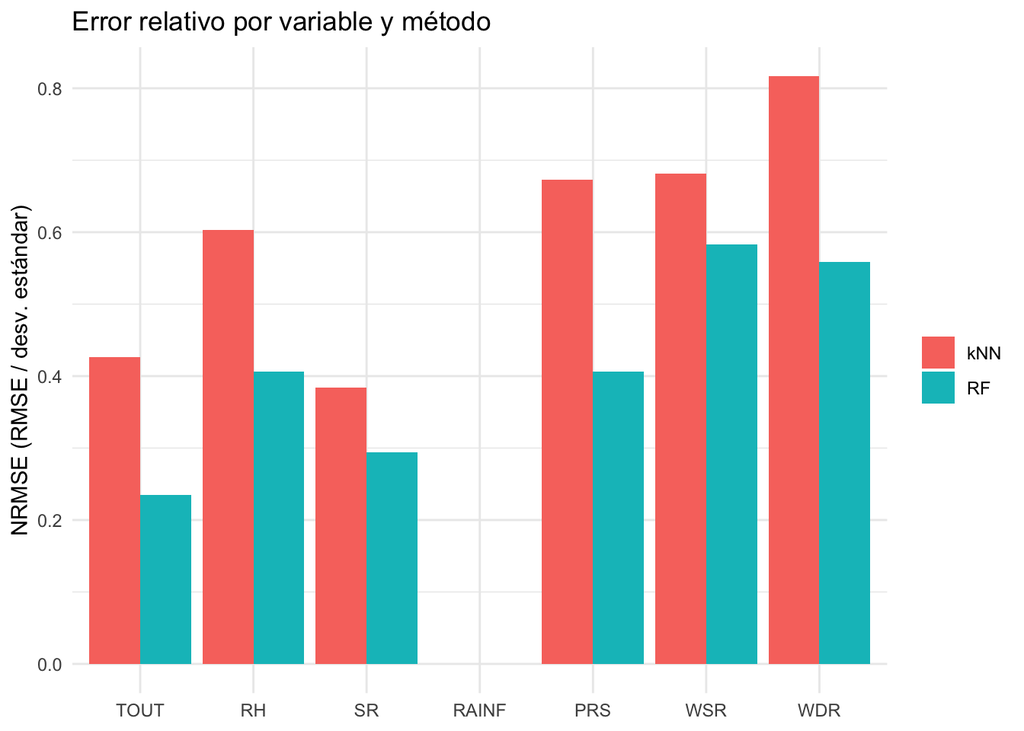

```r
metricas |>
  mutate(variable = factor(variable, vars_meteo)) |>
  group_by(variable, metodo) |> summarise(NRMSE = mean(NRMSE), .groups = "drop") |>
  ggplot(aes(variable, NRMSE, fill = metodo)) +
  geom_col(position = "dodge") +
  labs(x = NULL, y = "NRMSE (RMSE / desv. estándar)", fill = NULL,
       title = "Error relativo por variable y método")
```

### 5.3.2 Distribución: descriptivos, cajas, ECDF y Kolmogorov-Smirnov

**Código**

```r
serie <- map_dfr(res_val, "serie")

serie |>
  pivot_longer(c(Original, RF, kNN), names_to = "base", values_to = "valor") |>
  group_by(variable, base) |>
  summarise(media = mean(valor), mediana = median(valor), min = min(valor), max = max(valor), .groups = "drop") |>
  arrange(match(variable, vars_meteo), match(base, c("Original", "RF", "kNN"))) |>
  kable(digits = 3, caption = "Descriptivos: base original vs imputada (la media de WDR no es una medida circular)")
```

Descriptivos: base original vs imputada (la media de WDR no es una medida circular)

| variable | base | media | mediana | min | max |
| --- | --- | --- | --- | --- | --- |
| TOUT | Original | 23.591 | 23.930 | 0.5 | 40.200 |
| TOUT | RF | 23.589 | 23.920 | 0.5 | 40.200 |
| TOUT | kNN | 23.599 | 23.930 | 0.5 | 40.200 |
| RH | Original | 58.643 | 60.000 | 1.0 | 98.000 |
| RH | RF | 58.638 | 60.000 | 1.0 | 98.000 |
| RH | kNN | 58.657 | 60.000 | 1.0 | 98.000 |
| SR | Original | 0.163 | 0.038 | 0.0 | 0.923 |
| SR | RF | 0.163 | 0.039 | 0.0 | 0.923 |
| SR | kNN | 0.163 | 0.038 | 0.0 | 0.923 |
| RAINF | Original | 0.010 | 0.000 | 0.0 | 17.990 |
| RAINF | RF | 0.010 | 0.000 | 0.0 | 17.990 |
| RAINF | kNN | 0.009 | 0.000 | 0.0 | 17.990 |
| PRS | Original | 714.706 | 713.400 | 680.5 | 747.600 |
| PRS | RF | 714.706 | 713.400 | 680.5 | 747.600 |
| PRS | kNN | 714.705 | 713.400 | 680.5 | 747.600 |
| WSR | Original | 7.064 | 5.300 | 0.1 | 63.300 |
| WSR | RF | 7.064 | 5.300 | 0.1 | 63.300 |
| WSR | kNN | 7.058 | 5.300 | 0.1 | 63.300 |
| WDR | Original | 127.613 | 112.000 | 1.0 | 360.000 |
| WDR | RF | 127.018 | 111.000 | 0.0 | 359.881 |
| WDR | kNN | 127.843 | 111.000 | 0.0 | 359.000 |

**Código**

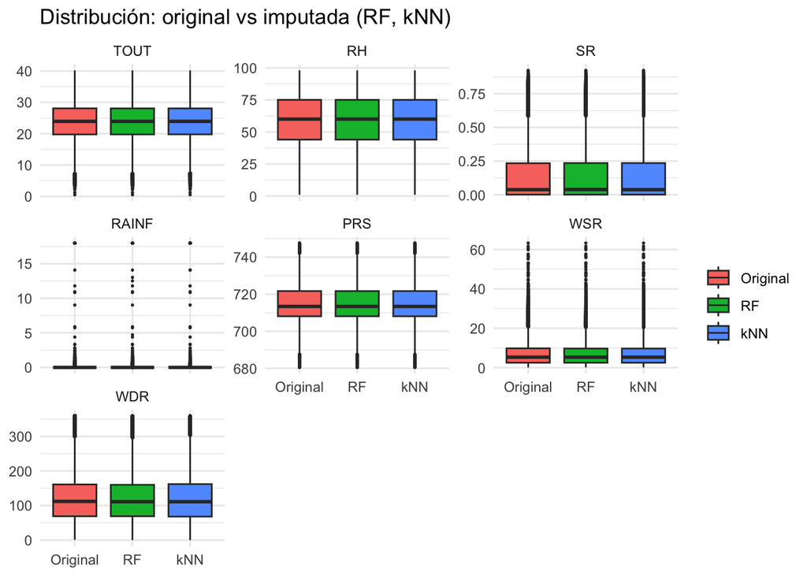

```r
serie |>
  pivot_longer(c(Original, RF, kNN), names_to = "base", values_to = "valor") |>
  mutate(variable = factor(variable, vars_meteo), base = factor(base, c("Original", "RF", "kNN"))) |>
  ggplot(aes(base, valor, fill = base)) +
  geom_boxplot(outlier.size = .3) +
  facet_wrap(~variable, scales = "free_y") +
  labs(x = NULL, y = NULL, fill = NULL, title = "Distribución: original vs imputada (RF, kNN)")
```

**Código**

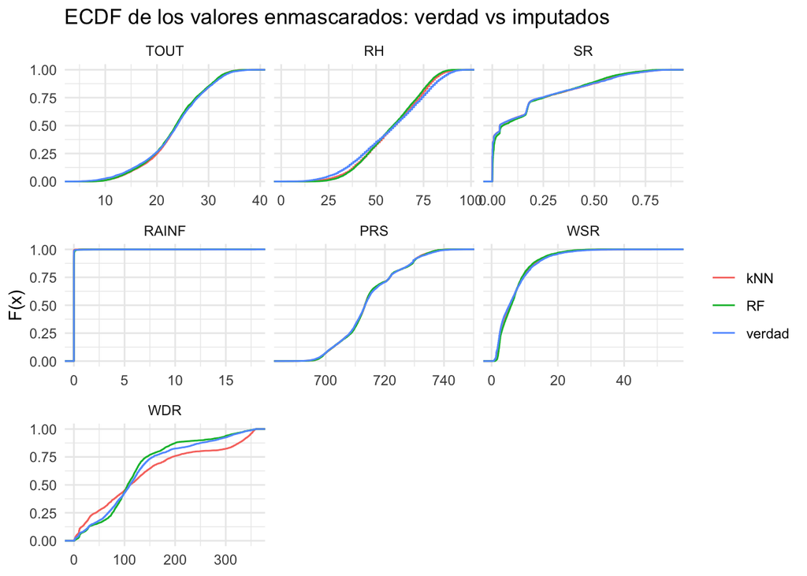

```r
map_dfr(res_val, "valores") |>
  pivot_longer(c(verdad, RF, kNN), names_to = "fuente", values_to = "valor") |>
  mutate(variable = factor(variable, vars_meteo)) |>
  ggplot(aes(valor, color = fuente)) +
  stat_ecdf() + facet_wrap(~variable, scales = "free_x") +
  labs(x = NULL, y = "F(x)", color = NULL,
       title = "ECDF de los valores enmascarados: verdad vs imputados")
```

Las pruebas KS se hacen en dos versiones. La primera es la del paper (serie completa original vs imputada), pero con solo `pct_mascara` de valores cambiados tiene muy poco poder para detectar diferencias. La segunda compara **solo los valores imputados contra los reales que se ocultaron**, que es más exigente. Se reporta el % de estaciones donde no se rechaza H0 (p ≥ 0.05).

**Código**

```r
metricas |>
  group_by(variable, metodo) |>
  summarise(`% estaciones no rechaza (serie completa)`  = mean(ks_p_completa  >= 0.05) * 100,
            `% estaciones no rechaza (solo imputados)`  = mean(ks_p_imputados >= 0.05) * 100,
            .groups = "drop") |>
  arrange(match(variable, vars_meteo), metodo) |>
  kable(digits = 0, caption = "Kolmogorov-Smirnov (alfa = 0.05): original vs imputado")
```

Kolmogorov-Smirnov (alfa = 0.05): original vs imputado

| variable | metodo | % estaciones no rechaza (serie completa) | % estaciones no rechaza (solo imputados) |
| --- | --- | --- | --- |
| TOUT | RF | 100 | 100 |
| TOUT | kNN | 100 | 100 |
| RH | RF | 100 | 64 |
| RH | kNN | 100 | 100 |
| SR | RF | 75 | 0 |
| SR | kNN | 100 | 100 |
| RAINF | RF | 45 | 27 |
| RAINF | kNN | 100 | 100 |
| PRS | RF | 100 | 75 |
| PRS | kNN | 100 | 92 |
| WSR | RF | 100 | 27 |
| WSR | kNN | 100 | 100 |
| WDR | RF | 70 | 10 |
| WDR | kNN | 60 | 0 |

### 5.3.3 Costo computacional

Cada estación se mide con los dos métodos, así que se contrasta la diferencia RF − k-NN con Shapiro-Wilk y, según su resultado, con t pareada o Wilcoxon pareada.

**Código**

```r
tiempos <- map_dfr(res_val, "tiempos")

tiempos |> group_by(metodo) |>
  summarise(across(c(user, sys, elapsed, vcells_mb, ncells_mb), mean), .groups = "drop") |>
  kable(digits = 3, caption = "Tiempo (s) y memoria máxima (MB) promedio por estación")
```

| metodo | user | sys | elapsed | vcells_mb | ncells_mb |
| --- | --- | --- | --- | --- | --- |
| RF | 37.798 | 0.469 | 19.541 | 294487318 | 5331255 |
| kNN | 5.278 | 0.250 | 1.732 | 216930672 | 10512110 |

**Código**

```r
map_dfr(c("user", "sys", "elapsed", "vcells_mb", "ncells_mb"), \(m) {
  w   <- tiempos |> select(estacion, metodo, x = all_of(m)) |> pivot_wider(names_from = metodo, values_from = x)
  dif <- w$RF - w$kNN
  sw  <- if (length(dif) >= 3 && sd(dif) > 0) shapiro.test(dif)$p.value else NA_real_
  normal <- !is.na(sw) && sw >= 0.05
  p <- tryCatch(
    if (normal) t.test(w$RF, w$kNN, paired = TRUE)$p.value
    else suppressWarnings(wilcox.test(w$RF, w$kNN, paired = TRUE)$p.value),
    error = \(e) NA_real_)
  tibble(recurso = m, shapiro_p = sw, prueba = if (normal) "t pareada" else "Wilcoxon pareada", p_value = p)
}) |> kable(digits = 4, caption = "Diferencia RF vs k-NN en tiempo y memoria")
```

Diferencia RF vs k-NN en tiempo y memoria

| recurso | shapiro_p | prueba | p_value |
| --- | --- | --- | --- |
| user | 0.6292 | t pareada | 0.0000 |
| sys | 0.2001 | t pareada | 0.0024 |
| elapsed | 0.5871 | t pareada | 0.0000 |
| vcells_mb | 0.8832 | t pareada | 0.0000 |
| ncells_mb | 0.1964 | t pareada | 0.0000 |

## 5.4 Elección del método por variable

**Código**

```r
ks_resumen <- metricas |> group_by(variable, metodo) |>
  summarise(pct_ks_imputados = mean(ks_p_imputados >= 0.05) * 100, .groups = "drop") |>
  pivot_wider(names_from = metodo, values_from = pct_ks_imputados, names_prefix = "ks_")

metodo_meteo <- tabla_metricas |> left_join(ks_resumen, by = "variable") |>
  mutate(metodo = case_when(
    ks_RF < 50 & ks_kNN >= 50 ~ "kNN",   # RF distorsiona la distribución en la mayoría de las estaciones
    RMSE_kNN < RMSE_RF        ~ "kNN",
    TRUE                      ~ "RF"
  ))
kable(metodo_meteo, digits = 0,
      caption = "Método elegido por variable meteorológica (RMSE + veto por Kolmogorov-Smirnov)")
```

Método elegido por variable meteorológica (RMSE + veto por Kolmogorov-Smirnov)

| variable | RMSE_RF | RMSE_kNN | MAE_RF | MAE_kNN | NRMSE_RF | NRMSE_kNN | Mejor_RMSE | Mejor_MAE | ks_RF | ks_kNN | metodo |
| --- | --- | --- | --- | --- | --- | --- | --- | --- | --- | --- | --- |
| TOUT | 1 | 3 | 1 | 2 | 0 | 0 | RF | RF | 100 | 100 | RF |
| RH | 8 | 11 | 6 | 8 | 0 | 1 | RF | RF | 64 | 100 | RF |
| SR | 0 | 0 | 0 | 0 | 0 | 0 | RF | RF | 0 | 100 | kNN |
| RAINF | 0 | 0 | 0 | 0 | NaN | NaN | RF | RF | 27 | 100 | kNN |
| PRS | 1 | 2 | 1 | 2 | 0 | 1 | RF | RF | 75 | 92 | RF |
| WSR | 2 | 3 | 2 | 2 | 1 | 1 | RF | RF | 27 | 100 | kNN |
| WDR | 46 | 67 | 29 | 46 | 1 | 1 | RF | RF | 10 | 0 | RF |

**Código**

```r
metodo_de <- function(v) {
  m <- metodo_meteo$metodo[metodo_meteo$variable == v]
  if (length(m) == 0) "RF" else m[1]
}
```

## 5.5 Aplicación a todas las estaciones y años

Para cada combinación estación-año se ajusta el imputador con las variables utilizables y **solo se reemplazan los NA**; los valores observados no se modifican. Las series excluidas en el diagnóstico quedan como estaban. El resultado de RF se guarda en `dir_cache` por estación-año, de modo que si se interrumpe se puede reanudar.

RF con 300 árboles y 10 iteraciones es lento (ver tiempos arriba, multiplicados por el número de estaciones-año). Si hace falta, se puede bajar `ntree_rf` o poner `paralelo <- TRUE`.

**Código**

```r
imputar_meteo_ea <- function(est, anio_a) {
  d  <- datos_lim |> filter(estacion == est, anio == anio_a) |> arrange(fecha)
  vs <- vars_usables(est, anio_a)
  W  <- d |> select(fecha, all_of(vars_meteo))
  imputado <- matrix(FALSE, nrow(d), length(vars_meteo), dimnames = list(NULL, vars_meteo))

  if (length(vs) >= 2 && anyNA(d[vs])) {
    X <- armar_X(d, vs)
    hay_rf  <- any(map_chr(vs, metodo_de) == "RF")
    hay_knn <- any(map_chr(vs, metodo_de) == "kNN")
    f <- file.path(dir_cache, sprintf("rf_%s_%s.rds", est, anio_a))
    i_rf <- if (!hay_rf) NULL else if (file.exists(f)) readRDS(f) else {
      r <- desarmar_X(imp_rf(X, paralelo), vs); saveRDS(r, f); r
    }
    i_knn <- if (hay_knn) desarmar_X(imp_knn(X), vs) else NULL
    for (v in vs) {
      falt <- is.na(d[[v]])
      fuente <- if (metodo_de(v) == "kNN") i_knn else i_rf
      if (is.null(fuente)) next
      W[[v]][falt] <- fuente[[v]][falt]
      imputado[falt, v] <- TRUE
    }
  }
  I <- as_tibble(imputado) |> mutate(fecha = d$fecha) |>
    pivot_longer(-fecha, names_to = "variable", values_to = "imputado")
  W |> pivot_longer(-fecha, names_to = "variable", values_to = "valor") |>
    left_join(I, by = c("fecha", "variable")) |>
    mutate(estacion = est, metodo = if_else(imputado, map_chr(variable, metodo_de), NA_character_))
}

combos <- datos_lim |> distinct(estacion, anio) |> mutate(estacion = as.character(estacion))
imp_meteo <- pmap_dfr(combos, \(estacion, anio) imputar_meteo_ea(estacion, anio))

imp_meteo |> group_by(variable) |>
  summarise(horas_imputadas = sum(imputado),
            `% NA antes`   = mean(is.na(valor) | imputado) * 100,
            `% NA después` = mean(is.na(valor)) * 100) |>
  arrange(match(variable, vars_meteo)) |>
  kable(digits = 2, format.args = list(big.mark = ","),
        caption = "Cobertura de las variables meteorológicas antes y después de imputar")
```

Cobertura de las variables meteorológicas antes y después de imputar

| variable | horas_imputadas | % NA antes | % NA después |
| --- | --- | --- | --- |
| TOUT | 35,526 | 7.31 | 3.03 |
| RH | 41,756 | 12.57 | 7.54 |
| SR | 29,872 | 5.78 | 2.18 |
| RAINF | 24,435 | 4.93 | 1.99 |
| PRS | 36,034 | 5.60 | 1.26 |
| WSR | 45,294 | 6.78 | 1.33 |
| WDR | 43,287 | 7.98 | 2.77 |

Lo que sigue en NA después de imputar son las series que se excluyeron a propósito (no medidas o con demasiados faltantes). Para unir todo en una sola tabla larga con los contaminantes:

**Código**

```r
imp_todo <- bind_rows(imp_final, imp_meteo |> select(fecha, estacion, variable, valor))
imp_todo |> count(variable) |> kable(caption = "Filas por variable en la tabla imputada completa")
```

Filas por variable en la tabla imputada completa

| variable | n |
| --- | --- |
| CO | 865440 |
| NO | 865440 |
| NO2 | 865440 |
| NOX | 865440 |
| O3 | 865440 |
| PM10 | 865440 |
| PM25 | 865440 |
| PRS | 831095 |
| RAINF | 831095 |
| RH | 831095 |
| SO2 | 865440 |
| SR | 831095 |
| TOUT | 831095 |
| WDR | 831095 |
| WSR | 831095 |

# 6 Preparación de los datos

Se parte de la base ya diagnosticada (`datos_lim`, sin valores fuera de rango) y de la base imputada (`imp_todo`: contaminantes con los métodos A/B/C y meteorología con RF/k-NN). El objetivo de esta etapa es dejar un conjunto **limpio, sin duplicados, sin valores espurios y con una estructura adecuada para el análisis multivariado**.

## 6.1 Selección del conjunto de datos

### 6.1.1 Ensamblar la base imputada en formato ancho

La imputación devuelve tablas largas (`fecha`, `estacion`, `variable`, `valor`). Se pasan a formato ancho, se restaura la malla horaria completa y se agregan **banderas** `imp_<variable>` que indican qué celdas se imputaron (para poder auditar o excluir datos imputados después).

**Código**

```r
vars_meteo <- c("TOUT", "RH", "SR", "RAINF", "PRS", "WSR", "WDR")
vars_cont  <- setdiff(vars, vars_meteo)

datos_imp <- imp_todo |>
  transmute(estacion = as.character(estacion), fecha, variable, valor) |>
  distinct(estacion, fecha, variable, .keep_all = TRUE) |>
  pivot_wider(names_from = variable, values_from = valor)

for (v in setdiff(vars, names(datos_imp))) datos_imp[[v]] <- NA_real_   # variable sin ninguna imputación

# Malla completa (una fila por estación y hora) + banderas de imputación
orig_na <- datos_lim |>
  transmute(estacion = as.character(estacion), fecha, across(all_of(vars), is.na, .names = "na_{.col}"))

datos_imp <- datos_lim |>
  transmute(estacion = as.character(estacion), fecha) |>
  left_join(datos_imp, by = c("estacion", "fecha")) |>
  left_join(orig_na, by = c("estacion", "fecha"))

for (v in vars) datos_imp[[paste0("imp_", v)]] <- datos_imp[[paste0("na_", v)]] & !is.na(datos_imp[[v]])
datos_imp <- datos_imp |>
  select(-starts_with("na_")) |>
  mutate(anio = year(fecha), mes = month(fecha), hora = hour(fecha), .after = fecha)

cat("Filas:", comma(nrow(datos_imp)), "| columnas:", ncol(datos_imp), "\n")
```

```
Filas: 831,095 | columnas: 35
```

### 6.1.2 Cobertura tras imputar y criterio de inclusión

Se mide el % de NA que **sigue** quedando por estación y variable. Las reglas de selección son:

1. **Variables redundantes:** `NOX` se define como `NO + NO2`, por lo que es combinación lineal casi exacta de otras dos columnas y causaría singularidad en PCA, análisis factorial y regresión. Se excluye (`vars_redundantes`).
2. **Variables muy incompletas:** una variable pasa el filtro en una estación si le quedan ≤ `max_na_sel` % de NA.
3. **Estaciones:** se conservan las que tienen **todas** las variables candidatas. Si quedan menos de `min_estaciones`, se descarta la variable (distinta del objetivo) que menos estaciones cubre y se repite (así se prioriza tener un conjunto de variables observado simultáneamente).
4. **Estación-año:** se eliminan los años en que la variable objetivo tiene más de `max_na_sel` % de NA.

**Código**

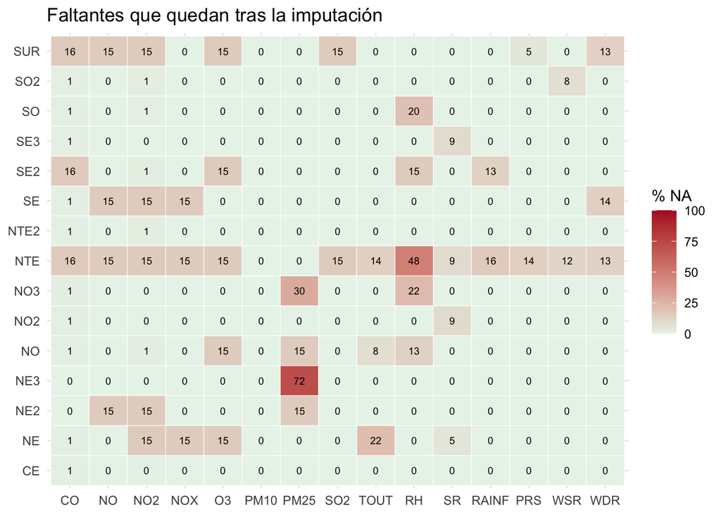

```r
objetivo_reg      <- "PM25"          # columna objetivo (regresión): concentración horaria de PM2.5
vars_redundantes  <- c("NOX")
max_na_sel        <- 30              # % máx. de NA residual para aceptar una variable en una estación
min_estaciones    <- 5               # mínimo de estaciones que se desea conservar
min_vars          <- 6               # mínimo de variables candidatas

cob_final <- map_dfr(vars, \(v) {
  datos_imp |> group_by(estacion) |>
    summarise(variable = v, pct_na = mean(is.na(.data[[v]])) * 100, .groups = "drop")
})

ggplot(cob_final |> mutate(variable = factor(variable, vars)),
       aes(variable, estacion, fill = pct_na)) +
  geom_tile(color = "white") + geom_text(aes(label = round(pct_na)), size = 2.5) +
  scale_fill_gradient(low = "#e8f4ea", high = "#b2182b", limits = c(0, 100)) +
  labs(x = NULL, y = NULL, fill = "% NA", title = "Faltantes que quedan tras la imputación")
```

**Código**

```r
candidatas <- setdiff(vars, vars_redundantes)
bitacora   <- tibble(variable = vars_redundantes, motivo = "Redundante: NOX = NO + NO2")
repeat {
  ok <- cob_final |> filter(variable %in% candidatas) |> mutate(ok = pct_na <= max_na_sel)
  cuenta_est <- ok |> group_by(estacion) |> summarise(todas = all(ok), .groups = "drop")
  est_ok <- cuenta_est$estacion[cuenta_est$todas]
  if (length(est_ok) >= min_estaciones || length(candidatas) <= min_vars) break
  peor <- ok |> filter(variable != objetivo_reg) |>                 # el objetivo nunca se descarta
    group_by(variable) |> summarise(n_ok = sum(ok), .groups = "drop") |> slice_min(n_ok, n = 1, with_ties = FALSE)
  bitacora   <- bind_rows(bitacora, tibble(variable = peor$variable,
                  motivo = sprintf("Solo %d estaciones con <= %d%% de NA", peor$n_ok, max_na_sel)))
  candidatas <- setdiff(candidatas, peor$variable)
}
stopifnot(objetivo_reg %in% candidatas)
if (length(est_ok) == 0) stop("Ninguna estación tiene todas las variables candidatas: relaja max_na_sel o min_vars.")

est_descartadas <- setdiff(unique(datos_imp$estacion), est_ok)
cat("Variables candidatas:", paste(candidatas, collapse = ", "), "\n")
```

```
Variables candidatas: CO, NO, NO2, O3, PM10, PM25, SO2, TOUT, RH, SR, RAINF, PRS, WSR, WDR
```

**Código**

```r
cat("Estaciones incluidas:", paste(est_ok, collapse = ", "), "\n")
```

```
Estaciones incluidas: CE, NE, NE2, NO, NO2, NO3, NTE2, SE, SE2, SE3, SO, SO2, SUR
```

**Código**

```r
cat("Estaciones excluidas:", if (length(est_descartadas)) paste(est_descartadas, collapse = ", ") else "ninguna", "\n")
```

```
Estaciones excluidas: NE3, NTE
```

**Código**

```r
kable(bitacora, caption = "Variables excluidas y motivo")
```

Variables excluidas y motivo

| variable | motivo |
| --- | --- |
| NOX | Redundante: NOX = NO + NO2 |

**Código**

```r
ea_ok <- datos_imp |> filter(estacion %in% est_ok) |>
  group_by(estacion, anio) |>
  summarise(pct_na_obj = mean(is.na(.data[[objetivo_reg]])) * 100, .groups = "drop") |>
  mutate(incluir = pct_na_obj <= max_na_sel)
kable(ea_ok |> filter(!incluir), digits = 1, caption = "Estación-año excluidos (objetivo con demasiados NA)")
```

Estación-año excluidos (objetivo con demasiados NA)

| estacion | anio | pct_na_obj | incluir |
| --- | --- | --- | --- |
| NE2 | 2025 | 100 | FALSE |
| NO | 2025 | 100 | FALSE |
| NO3 | 2022 | 100 | FALSE |
| NO3 | 2023 | 100 | FALSE |

**Código**

```r
col_id  <- c("estacion", "fecha", "anio", "mes", "hora")
datos_sel <- datos_imp |>
  semi_join(ea_ok |> filter(incluir), by = c("estacion", "anio")) |>
  filter(estacion %in% est_ok) |>
  select(all_of(col_id), all_of(candidatas), all_of(paste0("imp_", candidatas)))

tibble(Etapa = c("Base imputada completa", "Base seleccionada"),
       Filas = c(nrow(datos_imp), nrow(datos_sel)),
       Columnas = c(ncol(datos_imp), ncol(datos_sel)),
       Estaciones = c(n_distinct(datos_imp$estacion), n_distinct(datos_sel$estacion))) |>
  kable(format.args = list(big.mark = ","), caption = "Efecto de la selección")
```

Efecto de la selección

| Etapa | Filas | Columnas | Estaciones |
| --- | --- | --- | --- |
| Base imputada completa | 831,095 | 35 | 15 |
| Base seleccionada | 697,464 | 33 | 13 |

**Columnas objetivo.** `PM25` (numérica, para regresión) y, en la transformación, `calidad_aire` (categórica ordinal obtenida al discretizar el promedio móvil de 24 h de PM2.5, para clasificación). Ambas se justifican porque PM2.5 es el contaminante con mayor relevancia para la salud y el que el resto de la etapa ya toma como referencia.

## 6.2 Limpieza de datos

### 6.2.1 Duplicados

**Código**

```r
tibble(
  Control = c("Filas completamente duplicadas (base cruda)",
              "Marcas estación-hora repetidas (base cruda)",
              "Marcas estación-hora repetidas (base de trabajo, antes)"),
  Cantidad = c(sum(duplicated(crudo)),
               sum(duplicated(crudo[c("estacion", "fecha")])),
               sum(duplicated(datos_sel[c("estacion", "fecha")])))
) |> kable(format.args = list(big.mark = ","), caption = "Diagnóstico de duplicados")
```

Diagnóstico de duplicados

| Control | Cantidad |
| --- | --- |
| Filas completamente duplicadas (base cruda) | 0 |
| Marcas estación-hora repetidas (base cruda) | 0 |
| Marcas estación-hora repetidas (base de trabajo, antes) | 0 |

**Código**

```r
# Eliminación: se conserva la primera fila de cada estación-hora
datos_sel <- datos_sel |> distinct(estacion, fecha, .keep_all = TRUE)
stopifnot(!anyDuplicated(datos_sel[c("estacion", "fecha")]))
```

Los duplicados de la base cruda ya se eliminaron al construir la malla horaria (`distinct(estacion, fecha)`); aquí se verifica que no quedan en la base de trabajo.

### 6.2.2 Valores espurios o erróneos

Los valores centinela (−9999, 999) y los fuera de rango de SIMA ya se convirtieron en NA antes de imputar. Se resume cuántos fueron y se aplican dos correcciones que solo son posibles **después** de imputar: recortar a los límites físicos y restablecer las reglas de consistencia (los imputadores trabajan variable por variable y pueden romperlas).

**Código**

```r
fuera |> count(variable, sentido, name = "valores convertidos a NA") |>
  kable(format.args = list(big.mark = ","), caption = "Valores fuera del rango de SIMA (convertidos a NA antes de imputar)")
```

Valores fuera del rango de SIMA (convertidos a NA antes de imputar)

| variable | sentido | valores convertidos a NA |
| --- | --- | --- |
| CO | sobre el máximo | 24 |
| NO | sobre el máximo | 285 |
| NOX | sobre el máximo | 226 |
| O3 | sobre el máximo | 7 |
| PM10 | sobre el máximo | 3 |
| PRS | bajo el mínimo | 302 |
| PRS | sobre el máximo | 3 |
| RAINF | sobre el máximo | 36 |
| RH | sobre el máximo | 292 |
| SO2 | sobre el máximo | 1 |
| SR | bajo el mínimo | 270 |
| SR | sobre el máximo | 921 |
| TOUT | bajo el mínimo | 512 |
| TOUT | sobre el máximo | 5 |
| WSR | sobre el máximo | 1,704 |

**Código**

```r
# 1. Recorte a límites físicos
lim_fis <- function(v) if (v %in% names(lim_meteo)) lim_meteo[[v]] else c(0, Inf)
recorte <- tibble(variable = candidatas, `valores recortados` = 0L)
for (i in seq_along(candidatas)) {
  v <- candidatas[i]; x <- datos_sel[[v]]
  r <- pmin(pmax(x, lim_fis(v)[1]), lim_fis(v)[2])
  recorte$`valores recortados`[i] <- sum(x != r, na.rm = TRUE)
  datos_sel[[v]] <- r
}
kable(recorte |> filter(`valores recortados` > 0), caption = "Recorte a límites físicos tras imputar")
```

Recorte a límites físicos tras imputar

| variable | valores recortados |
| --- | --- |

**Código**

```r
# 2. Consistencia física: PM2.5 <= PM10 (se corrige el valor imputado; si ambos son observados no se toca)
if (all(c("PM25", "PM10") %in% names(datos_sel))) {
  v0 <- sum(datos_sel$PM25 > datos_sel$PM10, na.rm = TRUE)
  datos_sel <- datos_sel |>
    mutate(viol = !is.na(PM25) & !is.na(PM10) & PM25 > PM10,
           PM10 = if_else(viol & imp_PM10 & !imp_PM25, PM25, PM10),
           PM25 = if_else(viol & !(imp_PM10 & !imp_PM25) & imp_PM25, PM10, PM25)) |>
    select(-viol)
  cat("PM2.5 > PM10: antes", v0, "| después", sum(datos_sel$PM25 > datos_sel$PM10, na.rm = TRUE),
      "(las que quedan son ambos observados; se reportan, no se alteran)\n")
}
```

```
PM2.5 > PM10: antes 10675 | después 58 (las que quedan son ambos observados; se reportan, no se alteran)
```

**Código**

```r
# NOX ya se excluyó como redundante en la selección (NOX = NO + NO2); no hace falta reconstruirlo aquí.
```

### 6.2.3 Valores faltantes

Tras la imputación se revisa qué queda sin dato. **No se eliminan filas todavía**: los atributos derivados de la sección de transformación (promedios móviles, rezagos) necesitan la serie horaria contigua, así que las filas con NA residual se descartan al final, ya con los atributos construidos (`datos_modelo`).

**Código**

```r
tibble(variable = candidatas,
       `% NA residual` = map_dbl(candidatas, \(v) mean(is.na(datos_sel[[v]])) * 100),
       `% imputado` = map_dbl(candidatas, \(v) mean(datos_sel[[paste0("imp_", v)]]) * 100)) |>
  kable(digits = 2, caption = "Faltantes residuales y proporción imputada por variable")
```

Faltantes residuales y proporción imputada por variable

| variable | % NA residual | % imputado |
| --- | --- | --- |
| CO | 3.30 | 9.76 |
| NO | 3.78 | 12.21 |
| NO2 | 5.61 | 10.96 |
| O3 | 5.10 | 8.68 |
| PM10 | 0.00 | 4.06 |
| PM25 | 0.00 | 17.53 |
| SO2 | 1.26 | 10.68 |
| TOUT | 2.48 | 4.09 |
| RH | 3.96 | 4.28 |
| SR | 1.88 | 2.65 |
| RAINF | 1.08 | 2.74 |
| PRS | 0.37 | 4.18 |
| WSR | 0.64 | 5.21 |
| WDR | 2.26 | 5.26 |

**Código**

```r
cat("Filas con al menos un NA residual:", comma(sum(!complete.cases(datos_sel[candidatas]))),
    sprintf("(%.2f%% de %s)\n", mean(!complete.cases(datos_sel[candidatas])) * 100, comma(nrow(datos_sel))))
```

```
Filas con al menos un NA residual: 107,387 (15.40% de 697,464)
```

### 6.2.4 Datos categóricos

Las columnas categóricas originales son `estacion` (nominal). Se agrega la `zona` de la red (nominal, más interpretable que 13 estaciones) y `msnm` (elevación, numérica) a partir del catálogo.

**Código**

```r
zonas <- tribble(
  ~estacion, ~zona,        ~msnm,
  "SE", "Sureste", 500,   "NE", "Noreste", 474,   "CE", "Centro", 562,    "NO", "Noroeste", 568,
  "SO", "Suroeste", 674,  "NO2", "Noroeste", 702, "NTE", "Norte", 503,    "NE2", "Noreste", 432,
  "SE2", "Sureste", 387,  "SO2", "Suroeste", 636, "SE3", "Sureste", 334,  "SUR", "Sur", 555,
  "NTE2", "Norte", 520,   "NE3", "Noreste", 346,  "NO3", "Noroeste", 607)
stopifnot(all(datos_sel$estacion %in% zonas$estacion))
datos_sel <- datos_sel |> left_join(zonas, by = "estacion") |> mutate(zona = factor(zona))

tibble(columna = c("estacion", "zona", "mes", "hora"),
       tipo = c("Nominal", "Nominal", "Ordinal cíclica", "Ordinal cíclica"),
       niveles = c(n_distinct(datos_sel$estacion), n_distinct(datos_sel$zona), 12, 24)) |>
  kable(caption = "Variables categóricas / ordinales")
```

Variables categóricas / ordinales

| columna | tipo | niveles |
| --- | --- | --- |
| estacion | Nominal | 13 |
| zona | Nominal | 7 |
| mes | Ordinal cíclica | 12 |
| hora | Ordinal cíclica | 24 |

¿Cuándo hacen falta variables *dummy*? Depende del algoritmo:

| Análisis | ¿Dummies? | Comentario |
| --- | --- | --- |
| PCA, análisis factorial | No | Trabajan solo con variables numéricas continuas. |
| k-means, clustering jerárquico | No recomendado | Las dummies distorsionan la distancia euclidiana; mejor clusterizar solo numéricas e interpretar con la categoría después. |
| Regresión lineal / logística, LDA/QDA, SVM, redes, k-NN | **Sí** | Necesitan entradas numéricas. Con intercepto se usan *k − 1* niveles (regresión, LDA); con regularización o redes, *k*. |
| Árboles, random forest, boosting | No | Manejan categorías directamente. |
| Hora y mes | Mejor *sin* dummies | Son cíclicas: se codifican con seno/coseno (sección de atributos derivados). |

Se deja lista la función que construye las dummies y se usa al final sobre las categóricas nominales del conjunto de modelado.

**Código**

```r
hacer_dummies <- function(df, cols, k_menos_1 = TRUE) {
  d  <- df |> select(all_of(cols)) |> mutate(across(everything(), as.factor))
  f  <- as.formula(paste("~", paste(cols, collapse = " + ")))
  ca <- if (k_menos_1) NULL else lapply(d, contrasts, contrasts = FALSE)   # NULL = k-1; FALSE = k niveles
  mm <- model.matrix(f, model.frame(f, d, na.action = na.pass), contrasts.arg = ca)
  mm <- mm[, colnames(mm) != "(Intercept)", drop = FALSE]
  out <- as_tibble(mm); names(out) <- gsub("[^A-Za-z0-9_]", "_", chartr("áéíóúñ", "aeioun", names(out)))
  out
}
```

### 6.2.5 Valores atípicos (outliers)

En calidad del aire los valores extremos suelen ser **episodios reales** (incendios, inversiones térmicas, pólvora), no errores; los errores de instrumento ya se eliminaron con los rangos de SIMA. Por eso:

- Se **detectan** con la regla de Tukey (Q1 − 3·IQR, Q3 + 3·IQR; solo extremos, no atípicos leves), **por estación** (la presión y la temperatura difieren por altitud y microclima) y sobre la escala logarítmica en las variables con cola derecha.
- Se **marcan** en columnas `out_<variable>` (no se pierde la información) y se **winsorizan** en las variables predictoras, para que no dominen PCA, LDA o k-means.
- **No se winsorizan** la variable objetivo (`PM25`): si se recortan los episodios extremos, la clase “extremadamente mala” desaparecería del objetivo. Tampoco `SR`, `RAINF` (semicontinuas con muchos ceros, IQR = 0) ni `WDR` (circular).

**Código**

```r
k_iqr      <- 3
vars_out   <- intersect(c(vars_cont, "TOUT", "RH", "PRS", "WSR"), candidatas)
vars_log   <- intersect(c(vars_cont, "WSR"), candidatas)
no_winsor  <- objetivo_reg
tf  <- function(x, v) if (v %in% vars_log) log1p(x) else x
itf <- function(y, v) if (v %in% vars_log) expm1(y) else y

limites_out <- map_dfr(vars_out, \(v) {
  datos_sel |> group_by(estacion) |>
    summarise(variable = v, q1 = quantile(tf(.data[[v]], v), .25, na.rm = TRUE),
              q3 = quantile(tf(.data[[v]], v), .75, na.rm = TRUE), .groups = "drop") |>
    mutate(iqr = q3 - q1,
           lo = if_else(iqr > 0, pmax(itf(q1 - k_iqr * iqr, v), lim_fis(v)[1]), -Inf),
           hi = if_else(iqr > 0, itf(q3 + k_iqr * iqr, v), Inf))
})

datos_pre_out <- datos_sel                  # copia para comparar antes/después
resumen_out <- tibble(variable = vars_out, extremos = 0L, `% de observados` = 0, tratamiento = "")
for (i in seq_along(vars_out)) {
  v <- vars_out[i]; lim <- limites_out |> filter(variable == v)
  lo <- lim$lo[match(datos_sel$estacion, lim$estacion)]; hi <- lim$hi[match(datos_sel$estacion, lim$estacion)]
  es_out <- !is.na(datos_sel[[v]]) & (datos_sel[[v]] < lo | datos_sel[[v]] > hi)
  datos_sel[[paste0("out_", v)]] <- es_out
  if (v != no_winsor) datos_sel[[v]] <- pmin(pmax(datos_sel[[v]], lo), hi)
  resumen_out[i, -1] <- list(sum(es_out), mean(es_out[!is.na(datos_pre_out[[v]])]) * 100,
                             if (v == no_winsor) "solo marcado (objetivo)" else "marcado + winsorizado")
}
kable(resumen_out, digits = 3, format.args = list(big.mark = ","), caption = "Valores atípicos extremos (3 × IQR) por variable")
```

Valores atípicos extremos (3 × IQR) por variable

| variable | extremos | % de observados | tratamiento |
| --- | --- | --- | --- |
| CO | 87 | 0.013 | marcado + winsorizado |
| NO | 3,945 | 0.588 | marcado + winsorizado |
| NO2 | 16 | 0.002 | marcado + winsorizado |
| O3 | 1 | 0.000 | marcado + winsorizado |
| PM10 | 612 | 0.088 | marcado + winsorizado |
| PM25 | 106 | 0.015 | solo marcado (objetivo) |
| SO2 | 2,880 | 0.418 | marcado + winsorizado |
| TOUT | 0 | 0.000 | marcado + winsorizado |
| RH | 0 | 0.000 | marcado + winsorizado |
| PRS | 1,058 | 0.152 | marcado + winsorizado |
| WSR | 26 | 0.004 | marcado + winsorizado |

**Código**

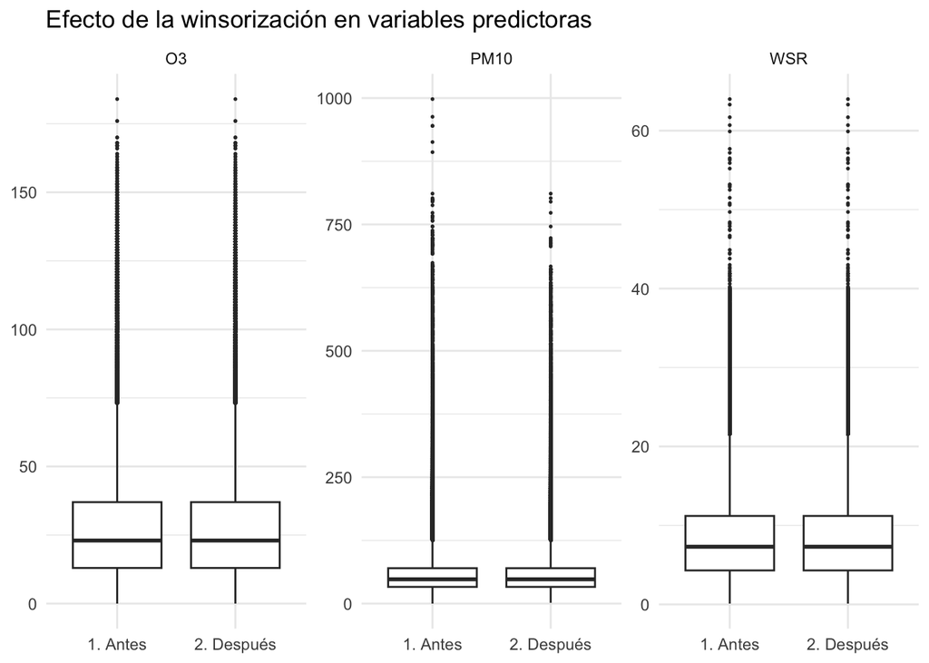

```r
vars_graf <- intersect(c("PM10", "O3", "WSR"), vars_out)
bind_rows(datos_pre_out |> mutate(etapa = "1. Antes"), datos_sel |> mutate(etapa = "2. Después")) |>
  select(etapa, all_of(vars_graf)) |>
  pivot_longer(-etapa, names_to = "variable", values_to = "valor") |>
  ggplot(aes(etapa, valor)) + geom_boxplot(outlier.size = .3) +
  facet_wrap(~variable, scales = "free_y") +
  labs(x = NULL, y = NULL, title = "Efecto de la winsorización en variables predictoras")
```

# 7 Transformación de los datos

Los tres incisos se resuelven en este orden: **(a) discretización → (c) atributos derivados → (b) escalado**. El escalado va al final para que los atributos derivados numéricos también queden en la escala común.

**Partición temporal.** Los parámetros que dependen de los datos (terciles, medias, desviaciones, mínimos y máximos) se calculan **solo con los años de entrenamiento** y se aplican al año de prueba, para no filtrar información del futuro.

**Código**

```r
anio_prueba <- 2025
stopifnot("Se necesitan al menos dos años para separar entrenamiento y prueba" = n_distinct(datos_sel$anio) > 1)
datos_sel <- datos_sel |>
  filter(anio <= anio_prueba) |>
  mutate(conjunto = if_else(anio < anio_prueba, "entrenamiento", "prueba"))
table(datos_sel$conjunto)
```

```
entrenamiento        prueba
       534960         96360
```

## 7.1 Discretización (binning)

Primero se revisa la asimetría: las variables muy sesgadas se **transforman** (sección de escalado) en lugar de discretizarse, y la discretización se reserva para los casos en que aporta algo (objetivo categórico, categorías con significado físico o calendario).

**Código**

```r
asimetria <- function(x) { x <- x[is.finite(x)]; mean(((x - mean(x)) / sd(x))^3) }
num_actuales <- setdiff(candidatas, "WDR")
tab_asim <- tibble(variable = num_actuales,
                   asimetria = map_dbl(num_actuales, \(v) asimetria(datos_sel[[v]][datos_sel$conjunto == "entrenamiento"])),
                   `% ceros` = map_dbl(num_actuales, \(v) mean(datos_sel[[v]] == 0, na.rm = TRUE) * 100)) |>
  arrange(desc(abs(asimetria)))
kable(tab_asim, digits = 2, caption = "Asimetría (entrenamiento) y % de ceros")
```

Asimetría (entrenamiento) y % de ceros

| variable | asimetria | % ceros |
| --- | --- | --- |
| RAINF | 43.16 | 98.51 |
| NO | 6.74 | 0.00 |
| PM25 | 5.18 | 0.03 |
| SO2 | 3.87 | 0.01 |
| PM10 | 3.36 | 0.00 |
| NO2 | 2.04 | 0.04 |
| SR | 1.41 | 37.14 |
| CO | 1.32 | 0.02 |
| O3 | 1.30 | 0.00 |
| WSR | 1.09 | 0.00 |
| TOUT | -0.36 | 0.01 |
| RH | -0.31 | 0.00 |
| PRS | 0.15 | 0.00 |

Decisiones de discretización:

| Variable | ¿Discretizar? | Razón |
| --- | --- | --- |
| `PM25` (promedio móvil de 24 h) | **Sí** → `calidad_aire` | Objetivo de clasificación con categorías oficiales. |
| `WDR` | **Sí** → `sector_viento` (8 sectores) | Circular; la categoría es interpretable (procedencia del aire). |
| `WSR` | Sí → `clase_viento` | Clases con significado físico (calma, ligera, moderada, fuerte). |
| `hora`, `mes` | Sí → `periodo_dia`, `temporada` | Agrupan ciclos diarios y estacionales. |
| `TOUT` | Sí, ejemplo → `tercil_temp` | Ejemplo de discretización por frecuencia igual (terciles del entrenamiento). |
| Contaminantes y resto | **No** | Se conservan continuos: discretizarlos pierde información y no hace falta para PCA/regresión. |

**Código**

```r
# Puntos de corte del promedio de 24 h de PM2.5 (ug/m3). Valores tomados del esquema de la NOM-172-SEMARNAT-2019;
# VERIFICAR contra la versión vigente (existe una actualización 2023) y ajustar aquí si difieren.
cortes_pm25 <- c(25, 45, 79, 147)
niveles_ca  <- c("Buena", "Aceptable", "Mala", "Muy mala", "Extremadamente mala")

# Promedio móvil hacia atrás con mínimo de 75 % de horas válidas en la ventana
media_movil <- function(x, n, min_prop = 0.75) {
  if (length(x) < n) return(rep(NA_real_, length(x)))
  ok <- !is.na(x)
  s  <- as.numeric(stats::filter(ifelse(ok, x, 0), rep(1, n), sides = 1))
  cn <- as.numeric(stats::filter(as.numeric(ok), rep(1, n), sides = 1))
  if_else(cn >= ceiling(min_prop * n), s / cn, NA_real_)
}

# Bloques de horas contiguas (si se excluyó un año intermedio, la ventana no debe cruzar el hueco)
datos_sel <- datos_sel |> arrange(estacion, fecha) |>
  group_by(estacion) |>
  mutate(bloque = cumsum(c(TRUE, diff(as.numeric(fecha)) != 3600))) |>
  group_by(estacion, bloque) |>
  mutate(PM25_24h = media_movil(PM25, 24)) |>
  ungroup()

q_temp <- quantile(datos_sel$TOUT[datos_sel$conjunto == "entrenamiento"], c(0, 1/3, 2/3, 1), na.rm = TRUE)

datos_sel <- datos_sel |>
  mutate(
    calidad_aire = cut(PM25_24h, c(-Inf, cortes_pm25, Inf), labels = niveles_ca, ordered_result = TRUE),
    periodo_dia  = cut(hora, c(-1, 5, 11, 17, 23), labels = c("madrugada", "mañana", "tarde", "noche")),
    temporada    = case_when(mes %in% c(12, 1, 2) ~ "invierno", mes %in% 3:5 ~ "primavera",
                             mes %in% 6:8 ~ "verano", TRUE ~ "otoño"),
    tercil_temp  = cut(TOUT, c(-Inf, q_temp[2], q_temp[3], Inf), labels = c("fresca", "templada", "cálida")),
    clase_viento = cut(WSR, c(-Inf, 6, 20, 39, Inf), labels = c("calma", "ligera", "moderada", "fuerte"), right = FALSE),
    sector_viento = cut((WDR + 22.5) %% 360, seq(0, 360, 45), right = FALSE,
                        labels = c("N", "NE", "E", "SE", "S", "SO", "O", "NO"))
  )

datos_sel |> filter(!is.na(calidad_aire)) |> count(calidad_aire) |>
  mutate(`%` = percent(n / sum(n), .1)) |>
  kable(format.args = list(big.mark = ","), caption = "Distribución del objetivo categórico (¡revisa el desbalance de clases!)")
```

Distribución del objetivo categórico (¡revisa el desbalance de clases!)

| calidad_aire | n | % |
| --- | --- | --- |
| Buena | 467,489 | 74.1% |
| Aceptable | 145,658 | 23.1% |
| Mala | 16,733 | 2.7% |
| Muy mala | 1,073 | 0.2% |
| Extremadamente mala | 68 | 0.0% |

## 7.2 Atributos derivados

Se construyen atributos con significado físico o que capturan la dinámica temporal. Todos usan solo información **pasada o simultánea** (no futura), para que sean válidos en un modelo predictivo.

| Atributo | Fórmula | Motivo |
| --- | --- | --- |
| `hora_sin`, `hora_cos`, `mes_sin`, `mes_cos` | seno y coseno de `2π·hora/24`, `2π·mes/12` | Codifica ciclos sin saltos artificiales (las 23 h están cerca de las 0 h). |
| `dia_semana`, `es_fin_semana` | calendario | El tráfico y la industria cambian entre semana y fin de semana. |
| `WDR_sin`, `WDR_cos` | seno y coseno de la dirección | La dirección es circular. |
| `viento_u`, `viento_v` | `−WSR·sin(WDR)`, `−WSR·cos(WDR)` | Componentes vectoriales del viento (convención meteorológica: dirección de *procedencia*). |
| `PM25_PM10` | `PM25 / PM10` | Fracción fina de las partículas (combustión vs. polvo). |
| `Ox` | `O3 + NO2` | Oxidante total, menos sensible a la titulación de O3 por NO. |
| `PM25_24h`, `PM10_24h`, `O3_8h`, `CO_8h` | promedios móviles hacia atrás | Coinciden con las ventanas de las normas. |
| `PM25_lag1`, `PM25_lag24` | valor 1 h y 24 h antes | Persistencia y ciclo diario. |

**Código**

```r
datos_sel <- datos_sel |>
  mutate(
    hora_sin = sin(2 * pi * hora / 24), hora_cos = cos(2 * pi * hora / 24),
    mes_sin  = sin(2 * pi * mes / 12),  mes_cos  = cos(2 * pi * mes / 12),
    dia_semana    = wday(fecha, label = TRUE, abbr = TRUE, week_start = 1, locale = "C"),
    es_fin_semana = wday(fecha, week_start = 1) >= 6)

if ("WDR" %in% names(datos_sel))
  datos_sel <- datos_sel |> mutate(WDR_sin = sin(WDR * pi / 180), WDR_cos = cos(WDR * pi / 180))
if (all(c("WSR", "WDR") %in% names(datos_sel)))
  datos_sel <- datos_sel |> mutate(viento_u = -WSR * sin(WDR * pi / 180), viento_v = -WSR * cos(WDR * pi / 180))
if (all(c("PM25", "PM10") %in% names(datos_sel)))
  datos_sel <- datos_sel |> mutate(PM25_PM10 = if_else(PM10 > 0, PM25 / PM10, NA_real_))
if (all(c("O3", "NO2") %in% names(datos_sel)))
  datos_sel <- datos_sel |> mutate(Ox = O3 + NO2)

# Promedios móviles y rezagos hacia atrás, dentro de bloques contiguos (solo si la variable existe)
movil <- function(df, v, n, nombre) {
  if (!v %in% names(df)) return(df)
  df |> group_by(estacion, bloque) |> mutate(!!nombre := media_movil(.data[[v]], n)) |> ungroup()
}
rezago <- function(df, v, k, nombre) {
  if (!v %in% names(df)) return(df)
  df |> group_by(estacion, bloque) |> mutate(!!nombre := dplyr::lag(.data[[v]], k)) |> ungroup()
}
datos_sel <- datos_sel |>
  movil("PM10", 24, "PM10_24h") |> movil("O3", 8, "O3_8h") |> movil("CO", 8, "CO_8h") |>
  rezago("PM25", 1, "PM25_lag1") |> rezago("PM25", 24, "PM25_lag24") |>
  select(-bloque)

derivados <- intersect(c("hora_sin", "hora_cos", "mes_sin", "mes_cos", "WDR_sin", "WDR_cos", "viento_u", "viento_v",
                         "PM25_PM10", "Ox", "PM25_24h", "PM10_24h", "O3_8h", "CO_8h", "PM25_lag1", "PM25_lag24"),
                       names(datos_sel))
tibble(atributo = derivados,
       min = map_dbl(derivados, \(v) min(datos_sel[[v]], na.rm = TRUE)),
       mediana = map_dbl(derivados, \(v) median(datos_sel[[v]], na.rm = TRUE)),
       media = map_dbl(derivados, \(v) mean(datos_sel[[v]], na.rm = TRUE)),
       max = map_dbl(derivados, \(v) max(datos_sel[[v]], na.rm = TRUE)),
       `% NA` = map_dbl(derivados, \(v) mean(is.na(datos_sel[[v]])) * 100)) |>
  kable(digits = 2, caption = "Resumen de atributos derivados numéricos (los NA iniciales de ventanas y rezagos se descartan después)")
```

Resumen de atributos derivados numéricos (los NA iniciales de ventanas y rezagos se descartan después)

| atributo | min | mediana | media | max | % NA |
| --- | --- | --- | --- | --- | --- |
| hora_sin | -1.00 | 0.00 | 0.00 | 1.00 | 0.00 |
| hora_cos | -1.00 | 0.00 | 0.00 | 1.00 | 0.00 |
| mes_sin | -1.00 | 0.00 | 0.00 | 1.00 | 0.00 |
| mes_cos | -1.00 | 0.00 | 0.00 | 1.00 | 0.00 |
| WDR_sin | -1.00 | 0.64 | 0.37 | 1.00 | 2.49 |
| WDR_cos | -1.00 | -0.07 | -0.01 | 1.00 | 2.49 |
| viento_u | -57.52 | -3.76 | -4.02 | 46.27 | 3.20 |
| viento_v | -53.75 | 0.35 | 0.34 | 39.50 | 3.20 |
| PM25_PM10 | 0.00 | 0.35 | 0.39 | 2.58 | 0.00 |
| Ox | 0.50 | 37.70 | 41.45 | 214.20 | 8.78 |
| PM25_24h | 2.00 | 18.12 | 20.47 | 275.24 | 0.05 |
| PM10_24h | 4.72 | 53.38 | 58.76 | 388.41 | 0.05 |
| O3_8h | 0.06 | 24.25 | 26.93 | 123.88 | 5.65 |
| CO_8h | 0.00 | 1.30 | 1.43 | 10.20 | 2.80 |
| PM25_lag1 | 0.00 | 17.00 | 20.47 | 782.00 | 0.00 |
| PM25_lag24 | 0.00 | 17.00 | 20.47 | 782.00 | 0.05 |

## 7.3 Escalado y normalización

Las variables tienen unidades y órdenes de magnitud muy distintos (presión ~ 700 mmHg vs. CO ~ 1 ppm). Los métodos basados en distancia o varianza (PCA, k-means, LDA, k-NN, SVM, redes) necesitan variables comparables. El procedimiento es:

1. **Transformación logarítmica** `log1p` a las variables no negativas con asimetría > `umbral_asimetria` (reduce la cola derecha típica de contaminantes).
2. **Estandarización** *z-score* (media 0, desviación 1) → para PCA, análisis factorial, LDA, k-means, regresión regularizada.
3. **Min-max** a [0, 1] → para redes neuronales y k-NN, o cuando se necesita acotar.

Los atributos ya acotados (`*_sin`, `*_cos`) y las categóricas no se escalan. La variable objetivo se conserva en sus unidades originales (y en su versión escalada por si se necesita).

Se descartan las filas con NA residual **ahora**, con todos los atributos ya calculados.

**Código**

```r
umbral_asimetria <- 1

vars_escalar <- intersect(c(setdiff(candidatas, "WDR"), "viento_u", "viento_v", "PM25_PM10", "Ox",
                            "PM25_24h", "PM10_24h", "O3_8h", "CO_8h", "PM25_lag1", "PM25_lag24", "msnm"),
                          names(datos_sel))

datos_modelo <- datos_sel |> filter(if_all(all_of(c(vars_escalar, "calidad_aire")), \(x) !is.na(x)))
cat("Filas antes:", comma(nrow(datos_sel)), "| después de quitar NA residuales:", comma(nrow(datos_modelo)), "\n")
```

```
Filas antes: 631,320 | después de quitar NA residuales: 552,503
```

**Código**

```r
# Parámetros ajustados SOLO con entrenamiento
ent <- datos_modelo |> filter(conjunto == "entrenamiento")
params_escala <- tibble(variable = vars_escalar) |>
  mutate(asimetria = map_dbl(variable, \(v) asimetria(ent[[v]])),
         minimo_raw = map_dbl(variable, \(v) min(ent[[v]])),
         transformacion = if_else(minimo_raw >= 0 & asimetria > umbral_asimetria, "log1p", "ninguna"),
         media = map2_dbl(variable, transformacion, \(v, t) mean(if (t == "log1p") log1p(ent[[v]]) else ent[[v]])),
         desv  = map2_dbl(variable, transformacion, \(v, t) sd(if (t == "log1p") log1p(ent[[v]]) else ent[[v]])),
         min_t = map2_dbl(variable, transformacion, \(v, t) min(if (t == "log1p") log1p(ent[[v]]) else ent[[v]])),
         max_t = map2_dbl(variable, transformacion, \(v, t) max(if (t == "log1p") log1p(ent[[v]]) else ent[[v]])))
kable(params_escala, digits = 3, caption = "Parámetros de transformación y escalado (ajustados con entrenamiento)")
```

Parámetros de transformación y escalado (ajustados con entrenamiento)

| variable | asimetria | minimo_raw | transformacion | media | desv | min_t | max_t |
| --- | --- | --- | --- | --- | --- | --- | --- |
| CO | 1.327 | 0.000 | log1p | 0.859 | 0.327 | 0.000 | 2.732 |
| NO | 6.816 | 0.300 | log1p | 2.020 | 0.870 | 0.262 | 6.217 |
| NO2 | 2.033 | 0.000 | log1p | 2.483 | 0.767 | 0.000 | 5.245 |
| O3 | 1.315 | 0.000 | log1p | 3.072 | 0.738 | 0.000 | 5.176 |
| PM10 | 3.377 | 1.605 | log1p | 3.977 | 0.575 | 0.958 | 6.688 |
| PM25 | 5.342 | 0.000 | log1p | 2.882 | 0.641 | 0.000 | 6.663 |
| SO2 | 3.988 | 0.000 | log1p | 1.653 | 0.444 | 0.000 | 3.891 |
| TOUT | -0.371 | -6.300 | ninguna | 23.177 | 7.169 | -6.300 | 44.630 |
| RH | -0.304 | 0.000 | ninguna | 57.125 | 20.638 | 0.000 | 100.000 |
| SR | 1.424 | 0.000 | log1p | 0.124 | 0.171 | 0.000 | 0.812 |
| RAINF | 43.399 | 0.000 | log1p | 0.004 | 0.085 | 0.000 | 4.317 |
| PRS | 0.157 | 684.400 | ninguna | 714.081 | 9.459 | 684.400 | 747.600 |
| WSR | 1.083 | 0.100 | log1p | 2.062 | 0.605 | 0.095 | 4.164 |
| viento_u | -0.019 | -39.997 | ninguna | -4.238 | 6.603 | -39.997 | 46.267 |
| viento_v | -0.264 | -53.750 | ninguna | 0.374 | 5.835 | -53.750 | 39.503 |
| PM25_PM10 | 1.010 | 0.000 | log1p | 0.304 | 0.134 | 0.000 | 1.276 |
| Ox | 1.329 | 0.500 | log1p | 3.636 | 0.470 | 0.405 | 5.364 |
| PM25_24h | 2.436 | 2.000 | log1p | 2.970 | 0.468 | 1.099 | 5.621 |
| PM10_24h | 1.513 | 4.722 | log1p | 4.048 | 0.434 | 1.744 | 5.713 |
| O3_8h | 1.003 | 0.839 | log1p | 3.154 | 0.593 | 0.609 | 4.827 |
| CO_8h | 1.207 | 0.000 | log1p | 0.863 | 0.319 | 0.000 | 2.416 |
| PM25_lag1 | 5.334 | 0.000 | log1p | 2.882 | 0.641 | 0.000 | 6.663 |
| PM25_lag24 | 5.333 | 0.000 | log1p | 2.882 | 0.641 | 0.000 | 6.663 |
| msnm | -0.194 | 334.000 | ninguna | 533.132 | 109.741 | 334.000 | 702.000 |

**Código**

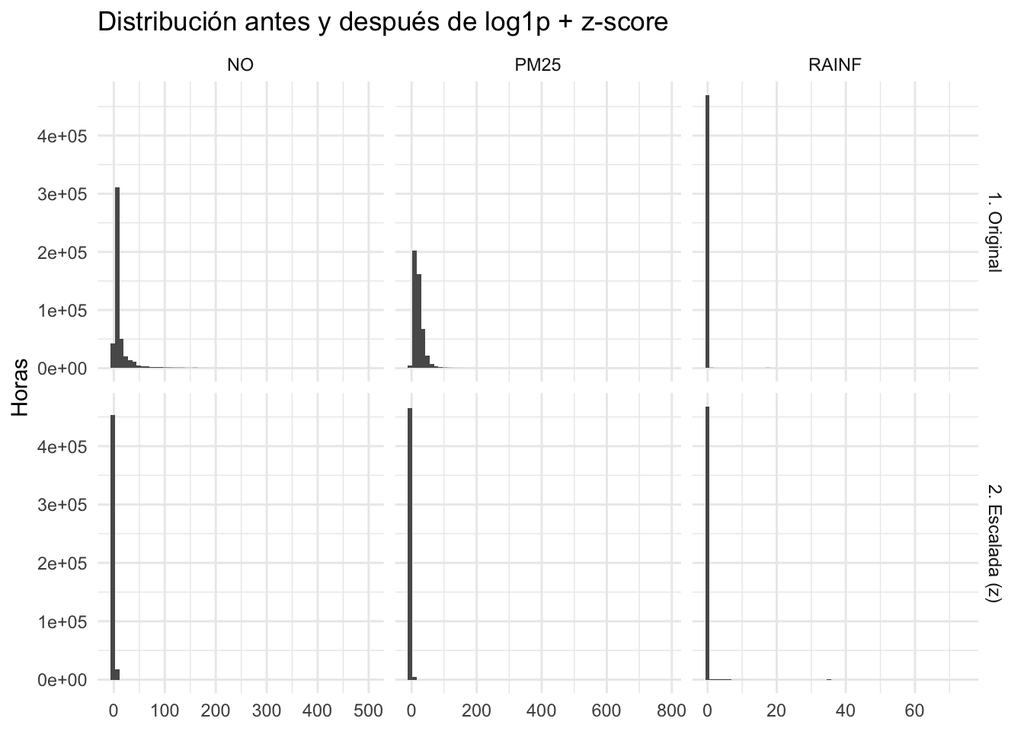

```r
# Función reutilizable: aplica los mismos parámetros a cualquier base nueva
aplicar_escala <- function(df, params, tipo = c("z", "mm")) {
  tipo <- match.arg(tipo)
  out <- df
  for (i in seq_len(nrow(params))) {
    p <- params[i, ]; x <- df[[p$variable]]
    if (p$transformacion == "log1p") x <- log1p(x)
    out[[paste0(p$variable, "_", tipo)]] <-
      if (tipo == "z") (x - p$media) / p$desv else (x - p$min_t) / (p$max_t - p$min_t)
  }
  out
}
datos_modelo <- datos_modelo |> aplicar_escala(params_escala, "z") |> aplicar_escala(params_escala, "mm")

# Efecto de la transformación en las variables más sesgadas
top_sesgo <- params_escala |> slice_max(asimetria, n = 3) |> pull(variable)
map_dfr(top_sesgo, \(v) bind_rows(
  tibble(variable = v, etapa = "1. Original", valor = ent[[v]]),
  tibble(variable = v, etapa = "2. Escalada (z)", valor = datos_modelo[[paste0(v, "_z")]][datos_modelo$conjunto == "entrenamiento"]))) |>
  ggplot(aes(valor)) + geom_histogram(bins = 60) + facet_grid(etapa ~ variable, scales = "free") +
  labs(x = NULL, y = "Horas", title = "Distribución antes y después de log1p + z-score")
```

**Código**

```r
# Correlaciones altas entre atributos (posible redundancia)
cm <- cor(ent[vars_escalar], use = "pairwise.complete.obs"); cm[upper.tri(cm, diag = TRUE)] <- NA
as.data.frame(as.table(cm)) |> filter(!is.na(Freq), abs(Freq) > 0.9) |> arrange(desc(abs(Freq))) |>
  rename(var1 = Var1, var2 = Var2, correlación = Freq) |>
  kable(digits = 3, caption = "Pares con |r| > 0.9 (considerar excluir uno según el análisis)")
```

Pares con |r| > 0.9 (considerar excluir uno según el análisis)

| var1 | var2 | correlación |
| --- | --- | --- |
| CO_8h | CO | 0.951 |

## 7.4 Dataset final para modelado

Se agregan las *dummies* de las categóricas nominales con `hacer_dummies()` (con *k − 1* niveles; usa `k_menos_1 = FALSE` para redes o modelos regularizados) y se guardan las bases.

**Código**

```r
dum <- hacer_dummies(datos_modelo, c("zona", "temporada", "periodo_dia"), k_menos_1 = TRUE)
datos_modelo_dummy <- bind_cols(datos_modelo, dum)

cat_finales <- c("estacion", "zona", "temporada", "periodo_dia", "dia_semana", "es_fin_semana",
                 "tercil_temp", "clase_viento", "sector_viento", "calidad_aire")

resumen_final <- tibble(
  Elemento = c("Filas", "Columnas", "Estaciones", "Periodo", "Objetivo numérico", "Objetivo categórico",
               "Entrenamiento / prueba"),
  Valor = c(comma(nrow(datos_modelo_dummy)), ncol(datos_modelo_dummy), n_distinct(datos_modelo_dummy$estacion),
            paste(format(min(datos_modelo_dummy$fecha), "%Y-%m-%d"), "a", format(max(datos_modelo_dummy$fecha), "%Y-%m-%d")),
            objetivo_reg, "calidad_aire",
            paste(comma(sum(datos_modelo_dummy$conjunto == "entrenamiento")), "/",
                  comma(sum(datos_modelo_dummy$conjunto == "prueba"))))
)
kable(resumen_final, caption = "Resumen del conjunto final")
```

Resumen del conjunto final

| Elemento | Valor |
| --- | --- |
| Filas | 552,503 |
| Columnas | 131 |
| Estaciones | 13 |
| Periodo | 2020-01-02 a 2025-12-31 |
| Objetivo numérico | PM25 |
| Objetivo categórico | calidad_aire |
| Entrenamiento / prueba | 470,522 / 81,981 |

**Código**

```r
saveRDS(datos_modelo_dummy, "salidas/datos_modelo.rds")
saveRDS(params_escala,      "salidas/params_escala.rds")
# El .rds conserva todo (banderas imp_/out_ y versión min-max); el .csv es una versión ligera para otras herramientas
readr::write_csv(datos_modelo_dummy |> select(-starts_with("imp_"), -starts_with("out_"), -ends_with("_mm")) |>
                   mutate(fecha = format(fecha, "%Y-%m-%d %H:%M:%S")), "salidas/datos_modelo.csv")
```